# Code used to generate paper results : CT characteristics

Julie Devis

2023-08-28

# 1 Loading data and packages

```r
library(readxl)
library(readr)
library(CTexploreR)
library(tidyverse)
library(SummarizedExperiment)
library(ComplexHeatmap)
library(circlize)
library(SingleCellExperiment)
library(msigdbr)
library(DOSE)
library(org.Hs.eg.db)
library(clusterProfiler)
library(patchwork)
library(Vennerable)
```

```r
load("../CTdata/eh_data/all_genes.rda")
load("../CTdata/eh_data/GTEX_data.rda")
load("../CTdata/eh_data/CCLE_data.rda")
load("../CTdata/eh_data/TCGA_TPM.rda")
load("../CTdata/eh_data/normal_tissues_multimapping_data.rda")
load("../CTdata/eh_data/mean_methylation_in_tissues.rda")
load("../CTdata/eh_data/DAC_treated_cells_multimapping.rda")
load("../CTdata/eh_data/DAC_treated_cells.rda")
load("../CTdata/eh_data/testis_sce.rda")
load("../CTdata/eh_data/FGC_sce.rda")
load("../CTdata/eh_data/oocytes_sce.rda")
load("../CTdata/eh_data/CT_genes.rda")

load("~/cluster/DataSets/FGC/scWGBS/processed_data/scWGBS_FGC_SE.rda")
load("~/cluster/CBIOProjects/202406_CT_genes_paper/tmp_data/CT_promoter_regions_hg19_GR.rda")


all_genes_clean <- all_genes %>%
  dplyr::rename(gene = external_gene_name) %>%
  mutate(Regulation = case_when(regulated_by_methylation ~ "Methylation",
                                !regulated_by_methylation ~
                                  "Not methylation")) %>%
  mutate(Chr = case_when(X_linked ~ "X-linked",
                         !X_linked ~ "not X")) %>%
  mutate(chr_met = case_when(regulated_by_methylation & X_linked ~ "X_met",
                             !regulated_by_methylation & X_linked ~ "X_not_met",
                             regulated_by_methylation & !X_linked ~ "not_X_met",
                             !regulated_by_methylation & !X_linked ~
                               "not_X_not_met")) %>%
  mutate(GTEX_specificity = case_when(GTEX_category == "testis_specific" ~
                                        "Testis specific",
                                        GTEX_category == "testis_preferential" ~
                                        "Testis preferential",
                                        GTEX_category == "lowly_expressed" ~
                                        "Undetectable in GTEX")) %>%
  mutate(GTEX_specificity = factor(GTEX_specificity,
                                     levels = c("Testis specific",
                                                "Undetectable in GTEX",
                                                "Testis preferential"))) %>%
  mutate(testis_specificity = case_when(testis_specificity ==
                                          "testis_specific" ~ "Testis specific",
                                        testis_specificity ==
                                          "testis_preferential" ~
                                          "Testis preferential")) %>%
  mutate(testis_specificity = factor(testis_specificity,
                                     levels = c("Testis specific",
                                                "Testis preferential"))) %>%
  mutate(chr_met = factor(chr_met,
                          levels = c("X_met", "not_X_met", "X_not_met",
                                     "not_X_not_met"))) %>%
  mutate(met_3_groups = case_when(regulated_by_methylation & X_linked ~
                                    "Methylation X-linked",
                                   regulated_by_methylation & !X_linked ~
                                    "Methylation not X-linked",
                             !regulated_by_methylation ~ "Not Methylation")) %>%
  mutate(met_3_groups = factor(met_3_groups,
                          levels = c("Methylation X-linked",
                                     "Methylation not X-linked",
                                     "Not Methylation")))

CT_genes <- all_genes %>%
  filter(CT_gene_type == "CT_gene")
CT_genes_types <- all_genes_clean %>%
  filter(CT_gene_type == "CT_gene")

CTP_genes <- all_genes %>%
  filter(CT_gene_type == "CTP_gene")
CTP_genes_types <- all_genes_clean %>%
  filter(CT_gene_type == "CTP_gene")
```

Common figures parameters

```r
legends_param <- list(
  labels_gp = gpar(col = "black", fontsize = 4),
  title_gp = gpar(col = "black", fontsize = 5, fontface = "bold"),
  simple_anno_size = unit(0.2, "cm"),
  row_names_gp = gpar(fontsize = 3),
  annotation_name_side = "left",
  border = FALSE,
  border_gp = gpar(lwd = 0.2),
  grid_width = unit(0.2, "cm"),
  grid_height = unit(0.05, "cm"),
  legend_height = unit(1, "cm"),
  use_raster = TRUE,
               raster_device = "CairoPNG",
               raster_quality = 10)



legend_colors <- c("#5E4FA2", "#3288BD", "#66C2A5", "#ABDDA4", "#E6F598",
                   "#FFFFBF", "#FEE08B", "#FDAE61", "#F46D43", "#D53E4F",
                   "#9E0142")

TCGA_colors <- c(
    "BRCA" = "midnightblue", "COAD" = "darkorchid2",
    "ESCA" = "gold", "HNSC" = "deeppink2",
    "LUAD" = "seagreen", "LUSC" = "seagreen3",
    "SKCM" = "red3")

CCLE_colors <- c(
    "Lung" = "seagreen3", "Skin" = "red3",
    "Bile_Duct" = "mediumpurple1", "Bladder" = "mistyrose2",
    "Colorectal" = "plum", "Lymphoma" = "steelblue1",
    "Uterine" = "darkorange4", "Myeloma" = "turquoise3",
    "Kidney" = "thistle4",
    "Pancreatic" = "darkmagenta", "Brain" = "palegreen2",
    "Gastric" = "wheat3", "Breast" = "midnightblue",
    "Bone" = "sienna1", "Head_and_Neck" = "deeppink2",
    "Ovarian" = "tan3", "Sarcoma" = "lightcoral",
    "Leukemia" = "steelblue4", "Esophageal" = "khaki",
    "Neuroblastoma" = "olivedrab1")

DAC_colors <- c(
    "B2-1" = "olivedrab2", "HCT116" = "lightcoral",
    "HEK293T" = "seagreen3", "HMLER" = "mediumpurple1",
    "IMR5-75" = "deeppink2", "NCH1681" = "steelblue2",
    "NCH612" = "red3", "TS603" = "darkmagenta")

DAC_treatment_colors <- c("CTL" = "royalblue4", "5-aza" = "maroon3")

Regulation_colors <- c("Methylation" = "indianred2",
                       "Not methylation"= "cyan4")

chr_met_colors = c("X_met" = "mediumorchid2",
                   "X_not_met" = "mediumseagreen",
                   "not_X_met"= "darkorange1",
                   "not_X_not_met" = "dodgerblue1")

Chr_colors = c("X-linked" = "deeppink3", "not X" = "lightgreen")
Chr_colors_with_Y = c("X-linked" = "deeppink3", "Autosome" = "lightgreen",
                      "Y-linked" = "black")

GTEX_specificity_colors = c("Testis specific" = "mediumpurple4",
                            "Testis preferential" = "goldenrod3",
                            "Undetectable in GTEX" = "gray")

Testis_specificity_colors = c("Testis specific" = "mediumpurple2",
                              "Testis preferential" = "goldenrod1",
                              "Undetectable in GTEX" = "gray")

testis_colors <- c(
    "SSC" = "floralwhite", "Spermatogonia" = "moccasin",
    "Early_spermatocyte" = "gold",
    "Late_spermatocyte" = "orange",
    "Round_spermatid" = "red2",
    "Elongated_spermatid" = "darkred", "Sperm" = "purple",
    "Sertoli" = "gray",
    "Leydig" = "cadetblue2", "Myoid" = "springgreen3",
    "Macrophage" = "gray10",
    "Endothelial" = "steelblue")

Fetal_cell_colors = c( "F_PGC" = "pink",
                       "F_GC" = "pink3",
                       "F_oogonia" = "palevioletred3",
                       "F_oocyte" = "mediumorchid4",
                       "M_PGC" = "lightblue1",
                       "M_GC" = "steelblue3",
                       "M_pre_spermatogonia" = "royalblue3")

Fetal_cellType_colors <- c(
"F_GC" = "pink3",
  "F_oogonia" = "palevioletred3",
  "F_oocyte" = "mediumorchid4",
  "M_GC" = "steelblue3",
  "M_pre_spermatogonia" = "royalblue3",
  "F_soma" = "gray",
  "M_soma" = "gray")

Fetal_time_colors <- c("6W" = "aliceblue",
                      "7W" = "cyan",
                      "8W" = "cyan4",
                      "9W" = "skyblue1",
                      "10W" = "dodgerblue",
                      "17W" = "blue",
                      "21W" = "lightblue4",
                      "24W" = "black")

oocytes_colors <- c("Growing oocytes" = "mediumpurple1",
                    # "Fully grown oocytes" ="lightgreen",
                     # "Metaphase I" = "mediumvioletred",
                    "Metaphase II" = "mediumpurple4")

sex_colors <- c("F" = "palevioletred1", "M"= "skyblue1")

stage_colors <- c( "pre-meiotic" = "peachpuff",
                   "meiotic"= "lightsalmon",
                   "post-meiotic" = "maroon4",
                   "somatic" = "gray")
```

# 2 CT selection

## 2.1 Pipeline figure values

Here is the code used to have all the values in the pipeline figure.

As a reminder testis_specificity has been done summarizing testis-specificity analysis from GTEX, multimapping, HPA_cell_type_specificities, CCLE and TCGA categories.

Testis-specific genes must be: classified as “testis-specific” in GTEX or multimappig analysis + must not be detected in any somatic cell type (in HPA scRNAseq analysis) + can not be classified as “leaky” in CLLE and TCGA categories + can not be detected (TPM > 0.5) in more than 75% of normal peritumoral tissues from a TCGA tumor type.

Testis_preferential genes must be: classified as “testis_preferential” in GTEX or multimappig analysis or initially classified as “testis-specific” in GTEX or multimappig analysis but downgraded to “testis_preferential because they were detected in a somatic cell type (in HPA scRNAseq analysis) + can be detected in some somatic cell type but the level has to be at least 10 times lower than the level detected in a germ cell type (in HPA scRNAseq analysis) must not be classified as”leaky” in CLLE and TCGA categories.

```r
table(all_genes$GTEX_category)
```

```
##
##     lowly_expressed               other testis_preferential     testis_specific
##                2663               19926                 330                1569
```

```r
table(all_genes$multimapping_analysis)
```

```
##
## not_testis_specific testis_preferential     testis_specific
##                2580                   7                  76
```

```r
table(all_genes$testis_specificity)
```

```
##
## not_testis_specific testis_preferential     testis_specific
##               22714                 281                1493
```

```r
table(all_genes$GTEX_category, all_genes$testis_specificity)
```

```
##
##                       not_testis_specific testis_preferential testis_specific
##   lowly_expressed                    2583                   6              74
##   other                             19926                   0               0
##   testis_preferential                  55                 275               0
##   testis_specific                     150                   0            1419
```

```r
specific_to_pref <- all_genes %>%
  filter(GTEX_category == "testis_specific" |
           multimapping_analysis == "testis_specific") %>%
  filter(testis_specificity == "testis_preferential")
# No more specific to pref as their ratio are all < 10
# all_genes %>%
#   filter(GTEX_category == "testis_specific" |
#            multimapping_analysis == "testis_specific") %>%
#   filter(!not_detected_in_somatic_HPA)

# Genes that were selected with GTEx but leaky so removed (ubiquitary expression)
all_genes %>%
  filter(GTEX_category %in% c("testis_specific", "testis_preferential")) %>%
  filter(TCGA_category == "leaky" | CCLE_category == "leaky") %>%
  dim()
```

```
## [1]  6 47
```

```r
specific_to_none <- all_genes %>%
  filter(GTEX_category == "testis_specific" |
           multimapping_analysis == "testis_specific") %>%
  filter(testis_specificity == "not_testis_specific")
table(specific_to_none$CCLE_category)
```

```
##
##       activated           leaky lowly_activated   not_activated
##              45               2               7              98
```

```r
table(specific_to_none$TCGA_category)
```

```
##
##          activated              leaky    lowly_activated multimapping_issue
##                106                  1                  2                  2
##      not_activated
##                 41
```

```r
table(specific_to_none$max_q75_in_NT < 0.5)
```

```
##
## FALSE  TRUE
##    95    57
```

```r
# 95 lost at this step
table(specific_to_none$not_detected_in_somatic_HPA)
```

```
##
## FALSE  TRUE
##    65    32
```

```r
table(specific_to_none$HPA_ratio_germ_som >= 10)
```

```
##
## FALSE  TRUE
##    65    31
```

```r
preferential_to_none <- all_genes %>%
  filter(GTEX_category == "testis_preferential" |
           multimapping_analysis == "testis_preferential") %>%
  filter(testis_specificity == "not_testis_specific")
table(preferential_to_none$CCLE_category)
```

```
##
##       activated lowly_activated   not_activated
##              34               4              18
```

```r
table(preferential_to_none$TCGA_category)
```

```
##
##          activated              leaky multimapping_issue      not_activated
##                 45                  3                  1                  7
```

```r
table(preferential_to_none$not_detected_in_somatic_HPA)
```

```
##
## FALSE  TRUE
##    53     2
```

```r
# Almost all detected in somatic
table(preferential_to_none$HPA_ratio_germ_som >= 10)
```

```
##
## FALSE  TRUE
##    53     2
```

```r
all_genes %>%
  filter(testis_specificity != "not_testis_specific") %>%
  filter(CCLE_category == "activated" &
           (TCGA_category == "multimapping_issue" |
              TCGA_category == "activated")) %>%
  pull(testis_specificity) %>%
  table()
```

```
## .
## testis_preferential     testis_specific
##                 144                 198
```

```r
table(all_genes$IGV_backbone)
```

```
##
## unclear
##      79
```

```r
table(all_genes$CT_gene_type)
```

```
##
##  CT_gene CTP_gene    other
##      146      134    24208
```

## 2.2 GTEX-TCGA-CCLE

Illustrate the selection using heatmaps with GTEx data, TCGA and CCLE

Function to print GTEX expression with specific annotations.

```r
print_GTEX_heatmap <- function(genes = NULL, units = "log_TPM",
                               row_fontsize = 2,
                               column_fontsize = 6,
                               h_width = 3,
                               h_height = 10,
                               split_rows_by = "regulation",
                               clust_method = "ward.D",
                               clustRow = FALSE) {

  suppressMessages({
    database <- GTEX_data
  })

  database <- database[rowData(database)$external_gene_name %in% genes, ]

  mat <- assay(database)
  rownames(mat) <- rowData(database)$external_gene_name

  if (units == "log_TPM") mat <- log1p(mat)

  gene_type <- all_genes_clean %>%
    filter(gene %in% genes) %>%
    mutate(gene = factor(gene, levels = genes)) %>%
    arrange(gene)


    if (split_rows_by == "regulation") {
        if (clustRow) gene_type <- gene_type %>%
            arrange(Regulation)
      rowSplit <- gene_type$Regulation
    }
    if (split_rows_by == "testis_specificity") {
        if (clustRow) gene_type <- gene_type %>%
            arrange(testis_specificity)
      rowSplit <- gene_type$testis_specificity
    }
    if (split_rows_by == "chr_met") {
      if (clustRow) gene_type <- gene_type %>%
          arrange(chr_met)
      rowSplit <- gene_type$chr_met
    }
    if (split_rows_by == "GTEX_specificity") {
      if (clustRow) GTEX_category <- gene_type %>%
          arrange(GTEX_specificity)
      rowSplit <- gene_type$GTEX_specificity
    }

  Regulation <- as.matrix(gene_type$Regulation)
  rownames(Regulation) <- gene_type$gene
  row_ha_regulation <- rowAnnotation(Regulation = Regulation,
                                     annotation_legend_param = legends_param,
                                     simple_anno_size = unit(0.2, "cm"),
                                     col = list(Regulation = Regulation_colors),
                                     annotation_name_gp = gpar(fontsize = 0))

  chr_met <- as.matrix(gene_type$chr_met)
  rownames(chr_met) <- gene_type$gene
  row_ha_chr_met <- rowAnnotation(chr_met = chr_met,
                                  annotation_legend_param = legends_param,
                                  simple_anno_size = unit(0.2, "cm"),
                                  col = list(chr_met = chr_met_colors),
                                  annotation_name_gp = gpar(fontsize = 0))

  Chr <- as.matrix(gene_type$Chr)
  rownames(Chr) <- gene_type$gene
  row_ha_chr <- rowAnnotation(Chr = Chr,
                              annotation_legend_param = legends_param,
                              simple_anno_size = unit(0.2, "cm"),
                              col = list(Chr = Chr_colors),
                              annotation_name_gp = gpar(fontsize = 0))

  GTEX_specificity <- as.matrix(gene_type$GTEX_specificity)
  rownames(GTEX_specificity) <- gene_type$gene
  row_ha_GTEX <- rowAnnotation(specificity = GTEX_specificity,
                             annotation_legend_param = legends_param,
                             simple_anno_size = unit(0.2, "cm"),
                             col = list(specificity =
                                          GTEX_specificity_colors),
                             annotation_name_gp = gpar(fontsize = 0))

  testis_specificity <- as.matrix(gene_type$testis_specificity)
  rownames(testis_specificity) <- gene_type$gene
  row_ha_TS <- rowAnnotation(testis_specificity = testis_specificity,
                             annotation_legend_param = legends_param,
                             simple_anno_size = unit(0.2, "cm"),
                             col = list(testis_specificity =
                                          Testis_specificity_colors),
                             annotation_name_gp = gpar(fontsize = 0))

  heatmap_colors <- colorRamp2(
    seq(0, 5, length = 11),
    legend_colors)

  h <- Heatmap(mat[as.vector(gene_type$gene), ],
               name = "log(TPM +1)",
               column_title = "Normal tissues (GTEx)",
               column_title_gp = gpar(fontsize = 6, face = "bold"),
               row_split = rowSplit,
               cluster_row_slices = FALSE,
               row_title_gp = gpar(fontsize = 6, face = "bold"),
               border = TRUE,
               border_gp = gpar(lwd = 0.5),
               col = heatmap_colors,
               cluster_rows = clustRow,
               cluster_columns = TRUE,
               show_row_dend = FALSE,
               show_column_dend = FALSE,
               row_names_gp = gpar(fontsize = row_fontsize),
               column_names_gp = gpar(fontsize = column_fontsize),
               column_names_side = "top",
               # right_annotation = c(row_ha_regulation,
               #                        row_ha_chr,
               #                        row_ha_ts,
               #                        gap = unit(1, "mm")),
               row_names_side = "left",
               width = unit(h_width, "cm"),
               height = unit(h_height, "cm"),
               clustering_method_rows = clust_method,
               use_raster = TRUE,
               raster_device = "CairoPNG",
               raster_quality = 10,
               heatmap_legend_param = legends_param)

  return(h)
}
```

Function to print TCGA expression with specific annotations and to downsample the number of tumor samples per tumor type.

```r
print_TCGA_heatmap <- function(genes = NULL,
                               tum_type = c("TCGA-SKCM", "TCGA-LUAD",
                                            "TCGA-LUSC", "TCGA-COAD",
                                            "TCGA-BRCA", "TCGA-HNSC",
                                            "TCGA-ESCA"),
                               downsample_to_n = 450,
                               fontsize = 4,
                               clust_method = "ward.D",
                               split_rows_by = "regulation",
                               h_width = 5,
                               h_height = 10,
                               show_annotation_legend = TRUE,
                               show_top_annotations = TRUE,
                               show_row_names = FALSE,
                               clustRow = FALSE,
                               clustCol = TRUE) {

  tcga <- TCGA_TPM
  tcga <- tcga[,tcga$shortLetterCode != "NT"]

  ## downsample tumors to have the same number of tumors in each type
  TCGA <- tcga[, tcga$project_id == tum_type[1]]
  TCGA <- TCGA[, 1:min(ncol(TCGA), downsample_to_n)]

  for (tum in tum_type[-1]){
    tmp <- tcga[, tcga$project_id == tum]
    tmp <- tmp[, 1:min(ncol(tmp), downsample_to_n)]
    TCGA <- cbind(TCGA, tmp)
  }

  TCGA$project_id <- gsub(pattern = "TCGA-", x = TCGA$project_id,
                          replacement = '')

  split_by <- factor(TCGA$project_id)

  column_ha_tumor <- HeatmapAnnotation(
    TCGA_tumor = TCGA$project_id,
    border = TRUE,
    col = list(TCGA_tumor = TCGA_colors),
    annotation_label = gpar(fontsize = 4),
    annotation_name_gp = gpar(fontsize = 0),
    simple_anno_size = unit(0.3, "cm"),
    annotation_legend_param = legends_param)

  ## Use gene names instead of ENSEMBL IDs
  mat <- SummarizedExperiment::assay(TCGA)
  rownames(mat) <- rowData(TCGA)$external_gene_name
  mat <- log1p(mat)

  gene_type <- all_genes_clean %>%
    filter(gene %in% genes) %>%
    mutate(gene = factor(gene, levels = genes)) %>%
    arrange(gene)


  rowSplit <- NULL
  if(!is.null(split_rows_by)){
    if (split_rows_by == "regulation") {
      if (clustRow) gene_type <- gene_type %>%
          arrange(Regulation)
      rowSplit <- gene_type$Regulation
    }
    if (split_rows_by == "testis_specificity") {
      if (clustRow) gene_type <- gene_type %>%
          arrange(testis_specificity)
      rowSplit <- gene_type$testis_specificity
    }
    if (split_rows_by == "GTEX_specificity") {
      if (clustRow) gene_type <- gene_type %>%
          arrange(GTEX_specificity)
      rowSplit <- gene_type$GTEX_specificity
    }

    if (split_rows_by == "chr_met") {
      if (clustRow) gene_type <- gene_type %>%
          arrange(chr_met)
      rowSplit <- gene_type$chr_met
    }
  }

  Regulation <- as.matrix(gene_type$Regulation)
  rownames(Regulation) <- gene_type$gene
  row_ha_regulation <- rowAnnotation(Regulation = Regulation,
                                     annotation_legend_param = legends_param,
                                     simple_anno_size = unit(0.2, "cm"),
                                     col = list(Regulation = Regulation_colors),
                                     annotation_name_gp = gpar(fontsize = 0))

  chr_met <- as.matrix(gene_type$chr_met)
  rownames(chr_met) <- gene_type$gene
  row_ha_chr_met <- rowAnnotation(chr_met = chr_met,
                                  annotation_legend_param = legends_param,
                                  simple_anno_size = unit(0.2, "cm"),
                                  col = list(chr_met = chr_met_colors),
                                  annotation_name_gp = gpar(fontsize = 0))

  Chr <- as.matrix(gene_type$Chr)
  rownames(Chr) <- gene_type$gene
  row_ha_chr <- rowAnnotation(Chr = Chr,
                              annotation_legend_param = legends_param,
                              simple_anno_size = unit(0.2, "cm"),
                              col = list(Chr = Chr_colors),
                              annotation_name_gp = gpar(fontsize = 0))

  GTEX_specificity <- as.matrix(gene_type$GTEX_specificity)
  rownames(GTEX_specificity) <- gene_type$gene
  row_ha_GTEX <- rowAnnotation(GTEX_specificity = GTEX_specificity,
                             annotation_legend_param = legends_param,
                             simple_anno_size = unit(0.2, "cm"),
                             col = list(GTEX_specificity =
                                          GTEX_specificity_colors),
                             annotation_name_gp = gpar(fontsize = 0))

  testis_specificity <- as.matrix(gene_type$testis_specificity)
  rownames(testis_specificity) <- gene_type$gene
  row_ha_TS <- rowAnnotation(specificity = testis_specificity,
                             annotation_legend_param = legends_param,
                             simple_anno_size = unit(0.2, "cm"),
                             col = list(testis_specificity =
                                          Testis_specificity_colors),
                             annotation_name_gp = gpar(fontsize = 0))

  rAnnot <- NULL
  if(show_annotation_legend){
    if (split_rows_by == "regulation") {
  rAnnot <- c(row_ha_regulation, gap = unit(1, "mm"))
    }
    if (split_rows_by == "testis_specificity") {
  rAnnot <- c(row_ha_TS, gap = unit(1, "mm"))
    }
    if (split_rows_by == "GTEX_specificity") {
  rAnnot <- c(row_ha_GTEX, gap = unit(1, "mm"))
    }

    if (split_rows_by == "chr_met") {
  rAnnot <- c(row_ha_TS, gap = unit(1, "mm"))
    }
  }


  # same range as in GTEX
  heatmap_colors <- colorRamp2(
    seq(0, 5, length = 11),
    legend_colors)

  tAnnot <- NULL
  if (show_top_annotations) tAnnot <- column_ha_tumor

  Heatmap(mat[as.vector(gene_type$gene), ],
          name = "TCGA (logTPM)",
          column_title = "TCGA tumor samples",
          column_title_gp = gpar(fontsize = 6, face = "bold"),
          clustering_method_rows = clust_method,
          clustering_method_columns = clust_method,
          column_split = split_by,
          row_gap = unit(c(1), "mm"),
          col = heatmap_colors,
          cluster_rows = clustRow,
          cluster_columns = clustCol,
          show_row_names = show_row_names,
          show_column_names = FALSE,
          show_row_dend = FALSE,
          show_column_dend = FALSE,
          column_names_gp = gpar(fontsize = 6),
          column_names_centered = TRUE,
          row_names_gp = gpar(fontsize = fontsize),
          row_names_side = "left",
          border = TRUE,
          border_gp = gpar(lwd = 0.5),
          column_names_side = c("top"),
          column_names_rot = 90,
          row_title_gp = gpar(fontsize = 0),
          top_annotation = tAnnot,
          right_annotation = rAnnot,
          row_split = rowSplit,
          cluster_row_slices = FALSE,
          width = unit(h_width, "cm"),
          height = unit(h_height, "cm"),
          use_raster = TRUE,
          raster_device = "CairoPNG",
          raster_quality = 10,
          heatmap_legend_param = legends_param,
          show_heatmap_legend = FALSE)
}
```

Function to print CCLE expression with specific annotations. Allows to downsample the number of tumor samples pet tumor type to show

```r
print_CCLE_heatmap <- function(genes = NULL,
                               tum_type = c("Skin", "Lung",
                                            "Colorectal",
                                            "Breast",
                                            "Head_and_Neck",
                                            "Esophageal"),
                               h_width = 5,
                               h_height = 10,
                               downsample_to_n = 450,
                               fontsize = 4,
                               clust_method = "ward.D",
                               split_rows_by = "regulation",
                               show_annotation_legend = TRUE,
                               clustRow = FALSE,
                               clustCol = TRUE){

  ## downsample tumors to have the same number of tumors in each type
  ccle <- CCLE_data
  CCLE <- ccle[, ccle$type == tum_type[1]]
  CCLE <- CCLE[, 1:min(ncol(CCLE), downsample_to_n)]

  for (tum in tum_type[-1]){
    tmp <- ccle[, ccle$type == tum]
    tmp <- tmp[, 1:min(ncol(tmp), downsample_to_n)]
    CCLE <- cbind(CCLE, tmp)
  }

  split_by <- factor(CCLE$type)

  column_ha_tumor <- HeatmapAnnotation(
    CCLE_cell_type = CCLE$type,
    border = TRUE,
    col = list(CCLE_cell_type = CCLE_colors),
    annotation_label = gpar(fontsize = 4),
    annotation_name_gp = gpar(fontsize = 0),
    simple_anno_size = unit(0.3, "cm"),
    annotation_legend_param = legends_param)

  ## Use gene names instead of ENSEMBL IDs
  mat <- SummarizedExperiment::assay(CCLE)
  rownames(mat) <- rowData(CCLE)$external_gene_name
  mat <- log1p(mat)


  gene_type <- all_genes_clean %>%
    filter(gene %in% genes) %>%
    mutate(gene = factor(gene, levels = genes)) %>%
    arrange(gene)

 rowSplit <- NULL
  if(!is.null(split_rows_by)){
    if (split_rows_by == "regulation") {
      if (clustRow) gene_type <- gene_type %>%
          arrange(Regulation)
      rowSplit <- gene_type$Regulation
    }
    if (split_rows_by == "testis_specificity") {
      if (clustRow) gene_type <- gene_type %>%
          arrange(testis_specificity)
      rowSplit <- gene_type$testis_specificity
    }
    if (split_rows_by == "GTEX_specificity") {
      if (clustRow) gene_type <- gene_type %>%
          arrange(GTEX_specificity)
      rowSplit <- gene_type$GTEX_specificity
    }

    if (split_rows_by == "chr_met") {
      if (clustRow) gene_type <- gene_type %>%
          arrange(chr_met)
      rowSplit <- gene_type$chr_met
    }
  }

  Regulation <- as.matrix(gene_type$Regulation)
  rownames(Regulation) <- gene_type$gene
  row_ha_regulation <- rowAnnotation(Regulation = Regulation,
                                     annotation_legend_param = legends_param,
                                     simple_anno_size = unit(0.2, "cm"),
                                     col = list(Regulation = Regulation_colors),
                                     annotation_name_gp = gpar(fontsize = 0))

  chr_met <- as.matrix(gene_type$chr_met)
  rownames(chr_met) <- gene_type$gene
  row_ha_chr_met <- rowAnnotation(chr_met = chr_met,
                                  annotation_legend_param = legends_param,
                                  simple_anno_size = unit(0.2, "cm"),
                                  col = list(chr_met = chr_met_colors),
                                  annotation_name_gp = gpar(fontsize = 0))

  Chr <- as.matrix(gene_type$Chr)
  rownames(Chr) <- gene_type$gene
  row_ha_chr <- rowAnnotation(Chr = Chr,
                              annotation_legend_param = legends_param,
                              simple_anno_size = unit(0.2, "cm"),
                              col = list(Chr = Chr_colors),
                              annotation_name_gp = gpar(fontsize = 0))

  GTEX_specificity <- as.matrix(gene_type$GTEX_specificity)
  rownames(GTEX_specificity) <- gene_type$gene
  row_ha_GTEX <- rowAnnotation(GTEX_specificity = GTEX_specificity,
                             annotation_legend_param = legends_param,
                             simple_anno_size = unit(0.2, "cm"),
                             col = list(GTEX_specificity =
                                          GTEX_specificity_colors),
                             annotation_name_gp = gpar(fontsize = 0))

  testis_specificity <- as.matrix(gene_type$testis_specificity)
  rownames(testis_specificity) <- gene_type$gene
  row_ha_TS <- rowAnnotation(specificity = testis_specificity,
                             annotation_legend_param = legends_param,
                             simple_anno_size = unit(0.2, "cm"),
                             col = list(testis_specificity =
                                          Testis_specificity_colors),
                             annotation_name_gp = gpar(fontsize = 0))

  rAnnot <- NULL
  if(show_annotation_legend){
    if (split_rows_by == "regulation") {
  rAnnot <- c(row_ha_regulation, gap = unit(1, "mm"))
    }
    if (split_rows_by == "testis_specificity") {
  rAnnot <- c(row_ha_TS, gap = unit(1, "mm"))
    }
    if (split_rows_by == "GTEX_specificity") {
  rAnnot <- c(row_ha_GTEX, gap = unit(1, "mm"))
    }

    if (split_rows_by == "chr_met") {
  rAnnot <- c(row_ha_TS, gap = unit(1, "mm"))
    }
  }


  # Same range as GTEX and TCGA
  heatmap_colors <- colorRamp2(
    seq(0, 5, length = 11),
    legend_colors)

  Heatmap(mat[as.vector(gene_type$gene), ],
          name = "CCLE (logTPM)",
          column_title = paste0("CCLE tumor cell lines"),
          column_title_gp = gpar(fontsize = 6, face = "bold"),
          clustering_method_rows = clust_method,
          clustering_method_columns = clust_method,
          column_split = split_by,
          row_gap = unit(c(1), "mm"),
          col = heatmap_colors,
          cluster_rows = clustRow,
          cluster_columns = clustCol,
          show_row_names = TRUE,
          show_column_names = FALSE,
          show_row_dend = FALSE,
          show_column_dend = FALSE,
          column_names_gp = gpar(fontsize = 6),
          column_names_centered = TRUE,
          row_names_gp = gpar(fontsize = fontsize),
          row_names_side = "left",
          border = TRUE,
          border_gp = gpar(lwd = 0.5),
          column_names_side = c("top"),
          column_names_rot = 90,
          row_title_gp = gpar(fontsize = 0),
          top_annotation = column_ha_tumor,
          right_annotation = rAnnot,
          row_split = rowSplit,
          width = unit(h_width, "cm"),
          height = unit(h_width, "cm"),
          use_raster = TRUE,
          raster_device = "CairoPNG",
          raster_quality = 10,
          heatmap_legend_param = legends_param,
          show_heatmap_legend = FALSE)
}
```

Show CT genes in GTEX, CCLE and TCGA (downsampling the number of samples by tumor type).

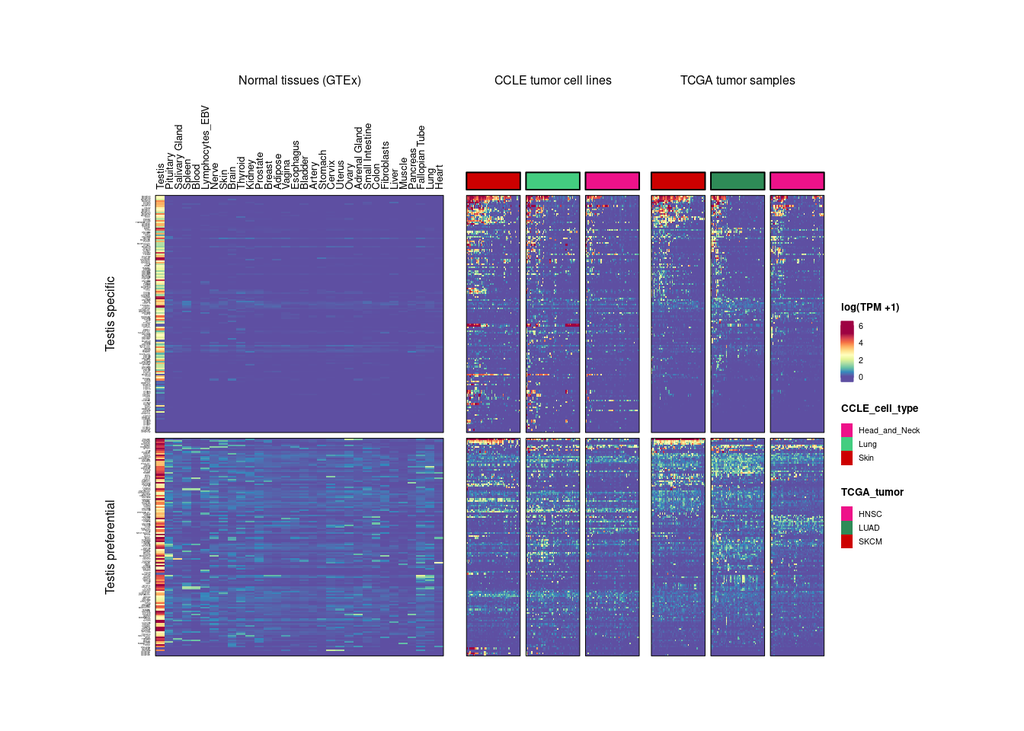

```r
my_genes <- all_genes %>%
  filter(CT_gene_type != "other") %>%
  pull(external_gene_name)

# Run the heatmap with custRow parameters to define the correct order
# This order will then be used for GTEX and CCLE heatmaps
ht_TCGA <- print_TCGA_heatmap(my_genes,
                              fontsize = 4,
                              downsample_to_n = 50,
                              h_width = 3,
                              h_height = 8,
                              tum_type = c("TCGA-SKCM", "TCGA-LUAD",
                                           #"TCGA-ESCA", "TCGA-LUSC",
                                           #"TCGA-COAD",
                                           #"TCGA-BRCA",
                                           "TCGA-HNSC"),
                              clust_method = "ward.D",
                              clustRow = TRUE,
                              split_rows_by = "testis_specificity")
indices <- row_order(ht_TCGA)
gene_order <- all_genes_clean %>%
  filter(gene %in% my_genes) %>%
  arrange(testis_specificity) %>%
  pull(gene)

TS_order <- gene_order[indices$`Testis specific`]
TP_order <- gene_order[indices$`Testis preferential`]
my_genes <- c(TS_order, TP_order)

ht_TCGA <- print_TCGA_heatmap(my_genes,
                              fontsize = 4,
                              downsample_to_n = 50,
                              h_width = 3,
                              h_height = 8,
                              tum_type = c("TCGA-SKCM", "TCGA-LUAD",
                                           #"TCGA-ESCA", "TCGA-LUSC",
                                           #"TCGA-COAD",
                                           #"TCGA-BRCA",
                                           "TCGA-HNSC"),
                              clust_method = "ward.D",
                              show_annotation_legend = FALSE,
                              clustRow = FALSE,
                              split_rows_by = "testis_specificity")

ht_CCLE <- print_CCLE_heatmap(my_genes,
                              downsample_to_n = 50,
                              tum_type = c("Skin", "Lung",
                                           #"colorectal",
                                           #"breast",
                                           #"esophageal",
                                           "Head_and_Neck"),
                              #"Leukemia", "Lymphoma"),
                              clustRow = FALSE,
                              show_annotation_legend = FALSE,
                              h_width = 3,
                              h_height = 8,
                              split_rows_by = "testis_specificity")


ht_GTEX <- print_GTEX_heatmap(my_genes,
                              row_fontsize = 1,
                              column_fontsize = 5,
                              h_width = 5,
                              h_height = 8,
                              clustRow = FALSE,
                              split_rows_by = "testis_specificity")

h_list <- ht_GTEX + ht_CCLE + ht_TCGA
draw(h_list, main_heatmap = "log(TPM +1)", ht_gap = unit(c(0.3, 0.01), "cm"),
     merge_legend = TRUE)
```

## 2.3 Multimapping Fig

Figure showing how we kept the lowly_expressed in GTEx

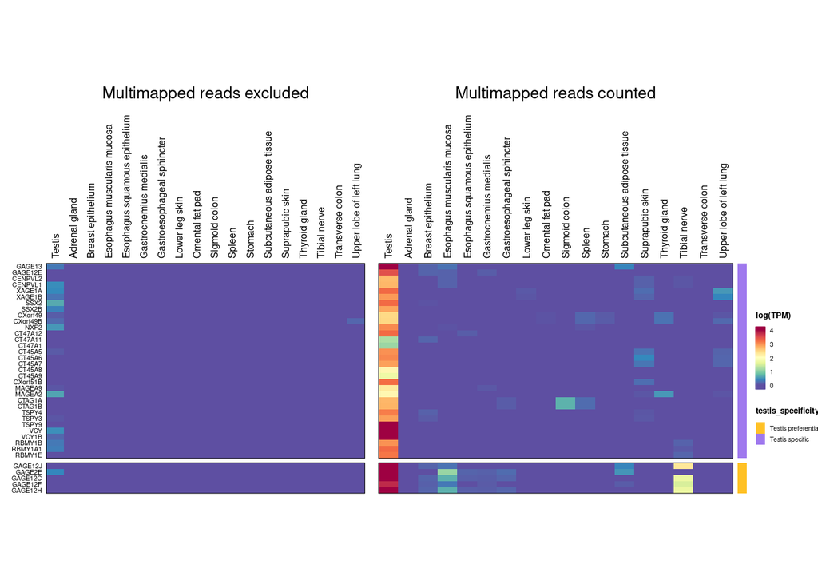

```r
my_genes <- all_genes_clean %>%
  filter(GTEX_category == 'lowly_expressed')  %>%
  filter(CT_gene_type != 'other')  %>%
    arrange(testis_specificity)
rowSplit <- my_genes$testis_specificity

testis_specificity <- as.matrix(my_genes$testis_specificity)
rownames(testis_specificity) <- my_genes$gene
row_ha_TS <- rowAnnotation(testis_specificity = testis_specificity,
                           annotation_legend_param = legends_param,
                           simple_anno_size = unit(0.2, "cm"),
                           col = list(testis_specificity =
                                        Testis_specificity_colors),
                           annotation_name_gp = gpar(fontsize = 0))

without_MP <- log1p(
  assay(normal_tissues_multimapping_data[my_genes$ensembl_gene_id,],
    "TPM_no_multimapping"))
with_MP <-  log1p(
  assay(normal_tissues_multimapping_data[my_genes$ensembl_gene_id,],
    "TPM_with_multimapping"))
rownames(without_MP) <- rownames(with_MP) <-
  rowData(normal_tissues_multimapping_data)[my_genes$ensembl_gene_id,
                                            ]$external_gene_name
# Fix same range of colors for both heatmaps
full_mat <- cbind(without_MP, with_MP)
heatmap_colors <- colorRamp2(
  seq(0, quantile(rowMax(full_mat), 0.8), length = 11), legend_colors)


colnames(without_MP) <- gsub("_", x = str_to_sentence(colnames(without_MP)),
                             ' ')
colnames(with_MP) <- gsub("_", x = str_to_sentence(colnames(with_MP)), ' ')
ordered_tissues <-
  c("Testis", colnames(without_MP)[- which(colnames(without_MP) == "Testis")])
h_without_MP <- Heatmap(without_MP[my_genes$gene, ordered_tissues],
                        name = "no MP",
                        column_title = "Multimapped reads excluded",
                        column_title_gp = gpar(fontsize = 10, face = "bold"),
                        row_title_gp = gpar(fontsize = 0, face = "bold",
                                            angle  = 90),
                        row_split = rowSplit,
                        border = TRUE,
                        border_gp = gpar(lwd = 0.5),
                        col = heatmap_colors,
                        cluster_rows = FALSE,
                        cluster_columns = FALSE,
                        show_row_dend = FALSE,
                        show_column_dend = FALSE,
                        row_names_gp = gpar(fontsize = 4),
                        column_names_gp = gpar(fontsize = 6),
                        column_names_side = "top",
                        row_names_side = "left",
                        heatmap_width = unit(8, "cm"),
                        heatmap_height = unit(12, "cm"),
                        clustering_method_rows = "ward.D",
                        use_raster = TRUE,
                        raster_device = "CairoPNG",
                        raster_quality = 10,
                        show_heatmap_legend = FALSE,
                        heatmap_legend_param = legends_param)

h_with_MP <- Heatmap(with_MP[my_genes$gene, ordered_tissues],
                     name = "log(TPM)",
                     column_title = "Multimapped reads counted",
                     column_title_gp = gpar(fontsize = 10, face = "bold"),
                     row_title_gp = gpar(fontsize = 0, face = "bold"),
                     row_split = rowSplit,
                     border = TRUE,
                     border_gp = gpar(lwd = 0.5),
                     col = heatmap_colors,
                     cluster_rows = TRUE,
                     cluster_columns = FALSE,
                     show_row_dend = FALSE,
                     show_column_dend = FALSE,
                     row_names_gp = gpar(fontsize = 4),
                     column_names_gp = gpar(fontsize = 6),
                     column_names_side = "top",
                     row_names_side = "left",
                     heatmap_width = unit(8, "cm"),
                     heatmap_height = unit(12, "cm"),
                     clustering_method_rows = "ward.D",
                     right_annotation = c(row_ha_TS, gap = unit(1, "mm")),
                     use_raster = TRUE,
                     raster_device = "CairoPNG",
                     raster_quality = 10,
                     heatmap_legend_param = legends_param)

h_list <- h_without_MP + h_with_MP
draw(h_list, main_heatmap = "no MP", ht_gap = unit(0.3, "cm"),
                 height = unit(5, "cm"))
```

## 2.4 IGV

Shows why we removed illegitimate transcripts

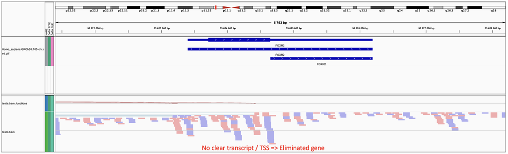

# 3 Methylation analysis

## 3.1 Regulation by methylation : WGBS + DAC heatmap

```r
met_genes <- CT_genes %>%
  filter(regulated_by_methylation) %>%
  pull(external_gene_name)

met_value_number_per_gene <- tibble(
  gene = CT_genes$external_gene_name,
  regulated_by_methylation = CT_genes$regulated_by_methylation,
  NA_met_values_number = rowSums(
    is.na(assay(mean_methylation_in_tissues[CT_genes$external_gene_name, ]))))
n_met_values <- ncol(mean_methylation_in_tissues)

CT_met_with_WGBS <- met_value_number_per_gene %>%
  filter(regulated_by_methylation) %>%
  filter(NA_met_values_number !=  n_met_values)

CT_met_without_WGBS <- met_value_number_per_gene %>%
  filter(regulated_by_methylation) %>%
  filter(NA_met_values_number == n_met_values)

CT_not_met_with_WGBS <- met_value_number_per_gene %>%
  filter(!regulated_by_methylation) %>%
  filter(NA_met_values_number !=  n_met_values)

CT_not_met_without_WGBS <- met_value_number_per_gene %>%
  filter(!regulated_by_methylation) %>%
  filter(NA_met_values_number == n_met_values)

mean_methylation_fig <- function(genes = NULL,
                                 values_only = FALSE,
                                 row_fontsize = 4,
                                 column_fontsize = 8,
                                 na.omit = FALSE) {

  database <- mean_methylation_in_tissues
  rowData(database)$external_gene_name <- rownames(database)
  database <- database[genes, ]

  if (na.omit) {
    mat <- na.omit(assay(database))
    clustering_option <- TRUE
  } else {
    mat <- assay(database)
    clustering_option <- FALSE
  }

  gene_type <- CT_genes_types %>%
    filter(gene %in% genes) %>%
    mutate(group = case_when(gene %in% CT_met_with_WGBS$gene ~ "group1",
                             gene %in% CT_met_without_WGBS$gene ~ "group2",
                             gene %in% CT_not_met_with_WGBS$gene ~ "group3",
                             gene %in% CT_not_met_without_WGBS$gene ~
                               "group4")) %>%
    left_join(CT_genes %>% dplyr::rename(gene = external_gene_name) %>%
                dplyr::select(gene, somatic_met_level, sperm_met_level,
                              germline_methylation, somatic_methylation)) %>%
    arrange(group, sperm_met_level)

  # sort genes regulated by met differently than not regulated by met
  gene_type_met <- gene_type %>%
    filter(regulated_by_methylation)

  gene_type_not_met <- gene_type %>%
    filter(!regulated_by_methylation) %>%
    arrange(germline_methylation, somatic_met_level)

  gene_type <- rbind(gene_type_met, gene_type_not_met)
  colnames(mat) <- str_to_sentence(colnames(mat))

  h <- Heatmap(mat[gene_type$gene, sort(colnames(mat))],
               column_title = "Promoter methylation",
               name = "Mean \nmethylation",
               column_title_gp = gpar(fontsize = 6),
               border = TRUE,
               border_gp = gpar(lwd = 0.5),
               row_title_gp = gpar(col = Regulation_colors, fontsize = 6),
               row_split = factor(gene_type$Regulation,
                                  levels = c("Methylation", "Not methylation")),
               #row_split = factor(gene_type$group),
               cluster_row_slices = FALSE,
               col = colorRamp2(seq_len(100),
                                colorRampPalette(c("moccasin",
                                                   "dodgerblue4"))(100)),
               na_col = "gray80",
               cluster_rows = FALSE,
               cluster_columns = FALSE,
               show_row_names = TRUE,
               show_heatmap_legend = TRUE,
               show_row_dend = FALSE,
               column_names_gp = gpar(fontsize = column_fontsize),
               row_names_gp = gpar(fontsize = row_fontsize),
               row_names_side = "left",
               heatmap_width = unit(4, "cm"),
               heatmap_height = unit(10, "cm"),
               use_raster = TRUE,
               raster_device = "CairoPNG",
               raster_quality = 8,
               column_names_side = "top",
               heatmap_legend_param = legends_param)

  return(h)
}
```

```r
DAC_fig <- function(genes = gene_type$gene,
                    multimapping = TRUE,
                    row_fontsize = 2,
                    units = "log1p",
                    values_only = FALSE, scale_lims = NULL) {


  if (multimapping) {
    # database <- CTdata::DAC_treated_cells_multimapping()
    database <- DAC_treated_cells_multimapping

  } else {
    #database <- CTdata::DAC_treated_cells()
    database <- DAC_treated_cells
  }

  database$treatment[database$treatment == "DAC"] <- "5-aza"
  database$treatment <- factor(database$treatment, levels = c("CTL", "5-aza"))
  gene_type <- CT_genes_types %>%
    filter(gene %in% genes) %>%
    mutate(group = case_when(gene %in% CT_met_with_WGBS$gene ~ "group1",
                             gene %in% CT_met_without_WGBS$gene ~ "group2",
                             gene %in% CT_not_met_with_WGBS$gene ~ "group3",
                             gene %in% CT_not_met_without_WGBS$gene ~ "group4")) %>%
    left_join(CT_genes %>% dplyr::rename(gene = external_gene_name) %>%
                dplyr::select(gene, somatic_met_level, sperm_met_level,
                              germline_methylation, somatic_methylation)) %>%
    arrange(group, sperm_met_level)

  # sort genes regulated by met differently than not regulated by met
  gene_type_met <- gene_type %>%
    filter(regulated_by_methylation)

  gene_type_not_met <- gene_type %>%
    filter(!regulated_by_methylation) %>%
    arrange(germline_methylation, somatic_met_level)

  gene_type <- rbind(gene_type_met, gene_type_not_met)
  rownames(database) <- rowData(database)$external_gene_name

  mat <- assay(database, units)

  df_col <- data.frame("cell" = colData(database)$cell,
                       "treatment" = colData(database)$treatment)
  rownames(df_col) <- rownames(colData(database))
  df_col <- df_col[order(df_col$cell, df_col$treatment), ]

  column_ha_cell <- HeatmapAnnotation(
    cell = df_col$cell,
    border = FALSE,
    #border_gp = gpar(lwd = 0.1),
    simple_anno_size = unit(0.2, "cm"),
    annotation_legend_param = legends_param,
    col = list("cell" = DAC_colors),
    annotation_name_gp = gpar(fontsize = 0))

  column_ha_treatment <- HeatmapAnnotation(
    treatment = df_col$treatment,
    col = list(treatment = DAC_treatment_colors),
    annotation_legend_param = legends_param,
    border = FALSE,
    simple_anno_size = unit(0.2, "cm"),
    annotation_name_gp = gpar(fontsize = 0))

  Regulation <- as.matrix(gene_type$Regulation)
  rownames(Regulation) <- gene_type$gene
  row_ha_regulation <- rowAnnotation(Regulation = Regulation,
                                     annotation_legend_param = legends_param,
                                     simple_anno_size = unit(0.2, "cm"),
                                     col = list(Regulation = Regulation_colors),
                                     annotation_name_gp = gpar(fontsize = 0))

  chr_met <- as.matrix(gene_type$chr_met)
  rownames(chr_met) <- gene_type$gene
  row_ha_chr_met <- rowAnnotation(chr_met = chr_met,
                                  annotation_legend_param = legends_param,
                                  simple_anno_size = unit(0.2, "cm"),
                                  col = list(chr_met = chr_met_colors),
                                  annotation_name_gp = gpar(fontsize = 0))

  Chr <- as.matrix(gene_type$Chr)
  rownames(Chr) <- gene_type$gene
  row_ha_chr <- rowAnnotation(Chr = Chr,
                              annotation_legend_param = legends_param,
                              simple_anno_size = unit(0.2, "cm"),
                              col = list(Chr = Chr_colors),
                              annotation_name_gp = gpar(fontsize = 0))

  testis_specificity <- as.matrix(gene_type$testis_specificity)
  rownames(testis_specificity) <- gene_type$gene
  row_ha_TS <- rowAnnotation(testis_specificity = testis_specificity,
                             annotation_legend_param = legends_param,
                             simple_anno_size = unit(0.2, "cm"),
                             col = list(testis_specificity =
                                          Testis_specificity_colors),
                             annotation_name_gp = gpar(fontsize = 0))
  if (is.null(scale_lims)) scale_lims <- c(0, quantile(rowMaxs(mat), 0.75))

  h <- Heatmap(mat[gene_type$gene, rownames(df_col), drop = FALSE],
               name = "logCounts",
               row_split = factor(gene_type$Regulation,
                                  levels = c("Methylation", "Not methylation")),
               row_title_gp = gpar(col = Regulation_colors, fontsize = 6),
               border = TRUE,
               border_gp = gpar(lwd = 0.5),
               column_title = "DAC induction in cell lines",
               column_title_gp = gpar(fontsize = 6),
               column_split = factor(df_col$cell),
               col = colorRamp2(seq(scale_lims[1], scale_lims[2], length = 11),
                                legend_colors),
               cluster_rows = TRUE,
               show_row_dend = FALSE,
               show_row_names = FALSE,
               clustering_method_rows = "ward.D",
               show_column_names = FALSE,
               cluster_columns = FALSE,
               row_names_gp = gpar(fontsize = row_fontsize),
               top_annotation = c(column_ha_cell, column_ha_treatment),
               # right_annotation = c(row_ha_ts,
               #                      #row_ha_regulation,
               #                      row_ha_chr,
               #                      gap = unit(1, "mm")),
               heatmap_width = unit(3.5, "cm"),
               heatmap_height = unit(10, "cm"),
               use_raster = TRUE,
               raster_device = "CairoPNG",
               raster_quality = 10,
               heatmap_legend_param = legends_param)

  return(h)
}
```

```r
fs <- 1.8
my_genes <- CT_genes %>%
  filter(!is.na(DAC_induced))
h_met <- mean_methylation_fig(genes = my_genes$external_gene_name,
                              values_only = FALSE,
                              row_fontsize = fs,
                              column_fontsize = 5,
                              na.omit = FALSE)
```

[output not shown]

```r
h_DAC <- DAC_fig(my_genes$external_gene_name,
                 multimapping = TRUE,
                 units = "log1p",
                 row_fontsize = fs)
```

[output not shown]

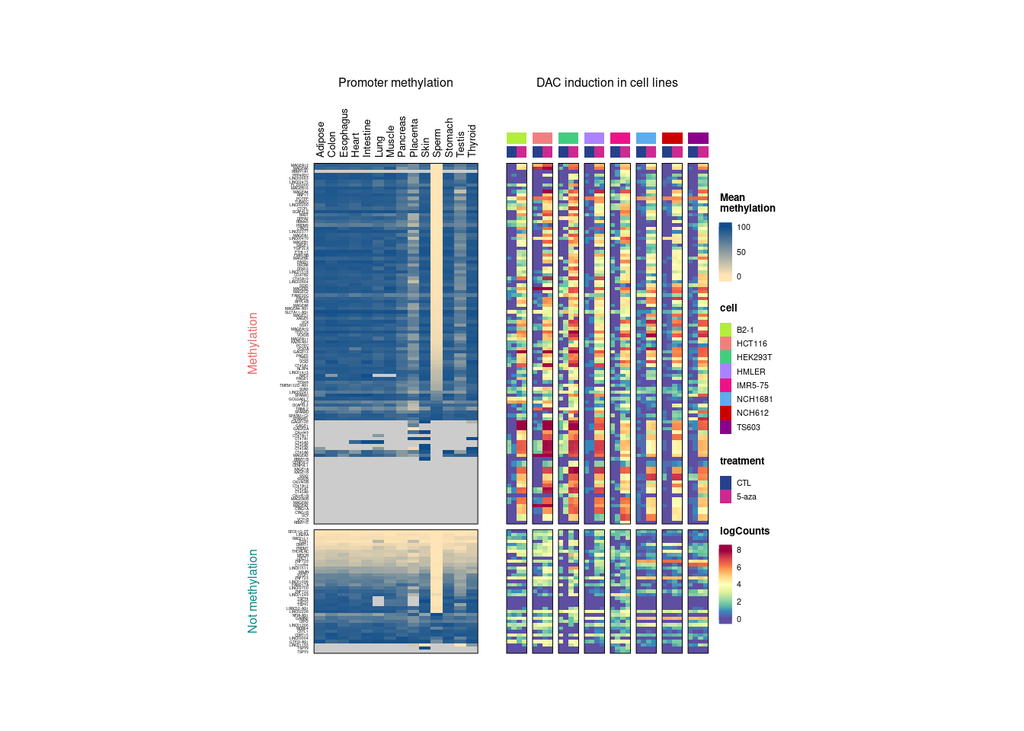

```r
h_list <- h_met + h_DAC
draw(h_list, main_heatmap = "Mean \nmethylation", ht_gap = unit(0.5, "cm"),
     merge_legend = TRUE)
```

## 3.2 Proportion of methylation regulated

```r
x <- enframe(table(CT_genes_types %>%
  filter(gene %in% CT_genes$external_gene_name) %>%
  pull(Regulation)), name = "Regulation") %>%
  left_join(enframe(prop.table(table(CT_genes_types$Regulation)),
                    name = "Regulation", value = "Percent"))
```

```
## Defaulting to continuous.
```

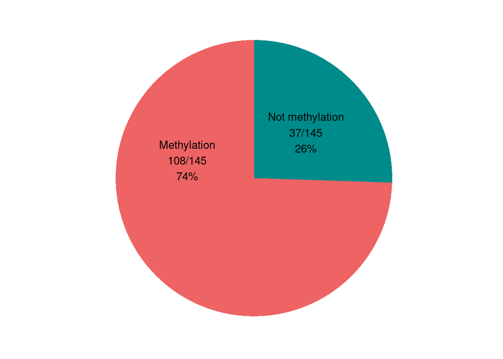

```r
met_prop_fig <- ggplot(x, aes(x = '', y = value, fill = Regulation)) +
  geom_bar(stat="identity", width=1) +
  coord_polar("y", start = 0) +
  geom_text(aes(y = value/5.5 + c(0, cumsum(value)[-length(value)]),
                label = rev(paste0(Regulation, "\n", value, "/",
                                   nrow(CT_genes_types %>%
                                          filter(!is.na(Regulation))), "\n",
                               round(Percent * 100), "%")))) +
  scale_fill_manual(values = Regulation_colors) +
  theme(axis.title.x = element_blank(),
        axis.title.y = element_blank(),
        legend.title = element_blank(),
        panel.background = element_blank(),
        panel.border = element_blank(),
        panel.grid = element_blank(),
        axis.ticks = element_blank(),
        axis.text.x = element_blank(),
        legend.position = "none")
met_prop_fig
```

```r
pdf(file = paste0("figs/Met_proportions.pdf"), width = 4, height = 4)
met_prop_fig
dev.off()
```

## 3.3 Enrichment on X chromosome

Genes regulated by methylation are enriched on the X chromosome.

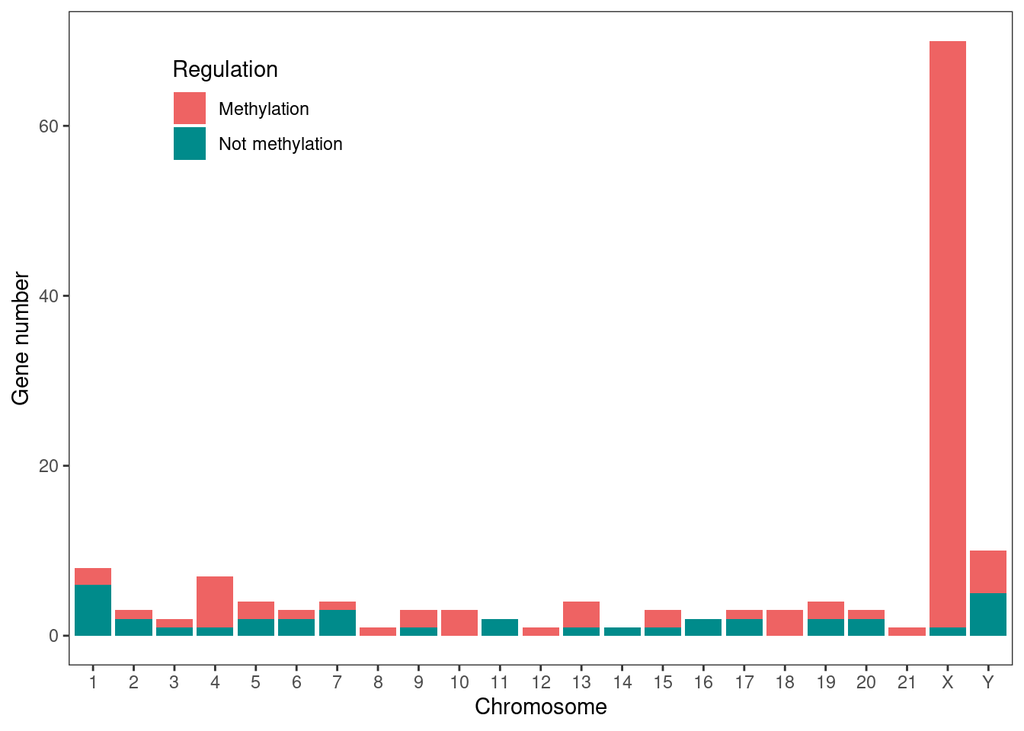

```r
CT_genes_types$chr <- factor(CT_genes_types$chr, levels = c(1:22, "X", "Y"))

fig_X_enrichment <- ggplot(CT_genes_types %>%
                             filter(!is.na(regulated_by_methylation)),
                           aes(x = chr, fill = Regulation)) +
  geom_bar(stat = 'count') +
  xlab("Chromosome") +
  ylab("Gene number") +
  scale_fill_manual(values = Regulation_colors) +
  theme_bw() +
  theme(legend.position = "inside",
        legend.position.inside = c(0.2, 0.85),
        #aspect.ratio = 1.5,
        panel.grid = element_blank())

fig_X_enrichment
```

Genes are enriched on the X chromosome (47.9452055%). Also, 108 genes have been flagged as regulated by methylation (73.9726027%). It is interesting to study the link between these two characteristics.

On the chromosome X, there is a clear enrichment of CT genes regulated by methylation (69 /70 chrX genes or 69/ 108 genes regulated by methylation).

## 3.4 Stats

### 3.4.1 Testis-specific and methylation

CT genes are enriched among testis-specific genes regulated by methylation. Proportion of Testis-specific genes regulated by methylation

```r
all_genes_chr <- all_genes %>%
  mutate(chr = case_when(chr == "X" ~ "X-linked",
                           chr == "Y" ~ "Y-linked",
                           !chr %in% c("X", "Y") ~ "Autosome"))

x <- table(met = all_genes_chr$regulated_by_methylation,
           testis_specificity = all_genes_chr$testis_specificity,
           useNA = "ifany")
x
```

```
##        testis_specificity
## met     not_testis_specific testis_preferential testis_specific
##   FALSE               20527                 217            1173
##   TRUE                 1855                  62             303
##   <NA>                  332                   2              17
```

```r
chisq.test(x[c("FALSE", "TRUE"), c("not_testis_specific", "testis_specific")])
```

```
##
##  Pearson's Chi-squared test with Yates' continuity correction
##
## data:  x[c("FALSE", "TRUE"), c("not_testis_specific", "testis_specific")]
## X-squared = 250.69, df = 1, p-value < 2.2e-16
```

```r
chisq.test(x[c("FALSE", "TRUE"), c("not_testis_specific",
                                   "testis_specific")])$p.value
```

```
## [1] 1.833125e-56
```

- 303/1476 (20.5284553 %) of Testis-specific are regulated by methylation

=> Significant enrichment of genes regulated by methylation among testis-specific genes (pval = 1.8331253^{-56})

Proportion of CT genes among Testis-specific genes regulated or not by methylation

```r
TS_genes <- all_genes_chr %>%
  filter(testis_specificity == "testis_specific")
x <- table(TS_genes = TS_genes$CT_gene_type, regulated_by_met = TS_genes$regulated_by_methylation)
x
```

```
##          regulated_by_met
## TS_genes  FALSE TRUE
##   CT_gene    37  108
##   other    1136  195
```

```r
chisq.test(x)
```

```
##
##  Pearson's Chi-squared test with Yates' continuity correction
##
## data:  x
## X-squared = 283.26, df = 1, p-value < 2.2e-16
```

```r
chisq.test(x)$p.value
```

```
## [1] 1.459863e-63
```

- 108 / 303 (35.6435644%) of TS genes regulated by methylation are CT genes
- 37 / 1173 (3.1543052%) of TS genes not regulated by methylation are CT genes

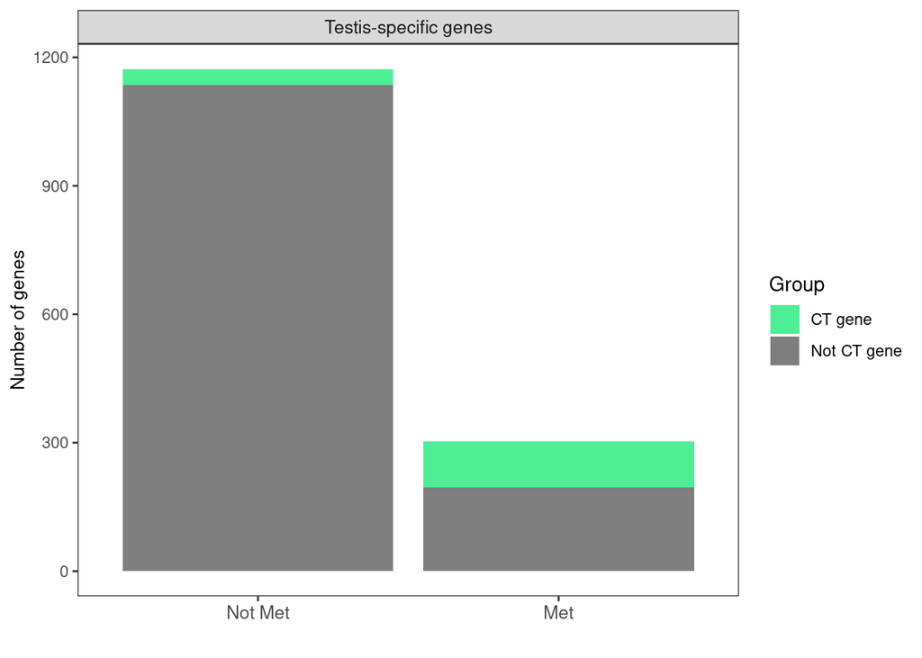

```r
fig_TS_CT_genes <- TS_genes %>%
  filter(!is.na(regulated_by_methylation)) %>%
  mutate(Regulation = case_when(regulated_by_methylation ~ "Met",
                                !regulated_by_methylation ~ "Not Met")) %>%
  mutate(Regulation = factor(Regulation, levels = c("Not Met", "Met"))) %>%
  mutate(Group = case_when(CT_gene_type == "CT_gene" ~ "CT gene",
                             CT_gene_type != "CT_gene" ~ "Not CT gene")) %>%
  group_by(Regulation, Group) %>%
  dplyr::count() %>%
  mutate(testis_specificity = "Testis-specific genes") %>%
  ggplot(aes(x = Regulation, y = n, fill = Group)) +
  geom_col() +
  scale_fill_manual(values = c("seagreen2", "gray50")) +
  xlab('') +
  ylab("Number of genes") +
  facet_wrap(~ testis_specificity) +
  theme_bw() +
  theme(legend.position = "right",
        plot.title = element_text(hjust = 0.5),
        panel.grid = element_blank(),
        strip.text = element_text(size = 10),
        axis.text.x = element_text(size = 10),
        axis.title.y = element_text(size = 10))
fig_TS_CT_genes
```

### 3.4.2 Chromosomal location

CT chromosomal location

```r
x <- table(gene = all_genes_chr$CT_gene_type, chr = all_genes_chr$chr)
x
```

```
##           chr
## gene       Autosome X-linked Y-linked
##   CT_gene        66       70       10
##   CTP_gene      122       12        0
##   other       23247      886       75
```

- 70 / 146 (47.9452055%) CT genes are X-linked

```r
CT_genes_chr <- all_genes_chr %>%
  filter(CT_gene_type == "CT_gene")

x <- table(chr = CT_genes_chr$chr,
           regulated_by_met = CT_genes_chr$regulated_by_methylation)
x
```

```
##           regulated_by_met
## chr        FALSE TRUE
##   Autosome    31   34
##   X-linked     1   69
##   Y-linked     5    5
```

- 69 / 70 (98.5714286%) of X-linked genes are regulated by methylation

```r
chisq.test(x[c("Autosome", "X-linked"), c("FALSE", "TRUE")])$p.value
```

```
## [1] 9.768218e-10
```

All genes Chromosomal location

```r
x <- table(chr = all_genes_chr$chr,
           testis_specificity = all_genes_chr$testis_specificity)
x
```

```
##           testis_specificity
## chr        not_testis_specific testis_preferential testis_specific
##   Autosome               21843                 267            1325
##   X-linked                 816                  14             138
##   Y-linked                  55                   0              30
```

```r
chisq.test(x[c("Autosome", "X-linked"), c("not_testis_specific",
                                          "testis_specific")])
```

```
##
##  Pearson's Chi-squared test with Yates' continuity correction
##
## data:  x[c("Autosome", "X-linked"), c("not_testis_specific", "testis_specific")]
## X-squared = 121.5, df = 1, p-value < 2.2e-16
```

```r
chisq.test(x[c("Autosome", "X-linked"), c("not_testis_specific",
                                          "testis_specific")])$p.value
```

```
## [1] 2.968847e-28
```

```r
chisq.test(x[c("Autosome", "Y-linked"), c("not_testis_specific",
                                          "testis_specific")])$p.value
```

```
## [1] 4.883772e-30
```

```r
chisq.test(x[c("Autosome", "X-linked"), c("not_testis_specific", "testis_preferential")])
```

```
##
##  Pearson's Chi-squared test with Yates' continuity correction
##
## data:  x[c("Autosome", "X-linked"), c("not_testis_specific", "testis_preferential")]
## X-squared = 1.1478, df = 1, p-value = 0.284
```

```r
chisq.test(x[c("Autosome", "Y-linked"), c("not_testis_specific", "testis_preferential")])
```

```
##
##  Pearson's Chi-squared test with Yates' continuity correction
##
## data:  x[c("Autosome", "Y-linked"), c("not_testis_specific", "testis_preferential")]
## X-squared = 0.040458, df = 1, p-value = 0.8406
```

### 3.4.3 Chromosomal location, testis specificity and regulation by methylation

Proportion of X-linked genes among Testis-specific genes regulated or not by methylation.

```r
TS_genes_chr <- all_genes_chr %>%
  filter(testis_specificity == "testis_specific")
x <- table(chr = TS_genes_chr$chr,
           TS_genes_regulated_by_met = TS_genes_chr$regulated_by_methylation,
           useNA = "ifany")
x
```

```
##           TS_genes_regulated_by_met
## chr        FALSE TRUE <NA>
##   Autosome  1117  191   17
##   X-linked    35  103    0
##   Y-linked    21    9    0
```

- 103 / 303 (33.9933993%) of testis-specific genes regulated by methylation are X-linked
- 35 / 1173 (2.9838022%) of testis-specific genes not regulated by methylatoin are X-linked

```r
chisq.test(x[c("Autosome", "X-linked"), c("FALSE", "TRUE")])
```

```
##
##  Pearson's Chi-squared test with Yates' continuity correction
##
## data:  x[c("Autosome", "X-linked"), c("FALSE", "TRUE")]
## X-squared = 274.06, df = 1, p-value < 2.2e-16
```

```r
chisq.test(x[c("Autosome", "X-linked"), c("FALSE", "TRUE")])$p.value
```

```
## [1] 1.475811e-61
```

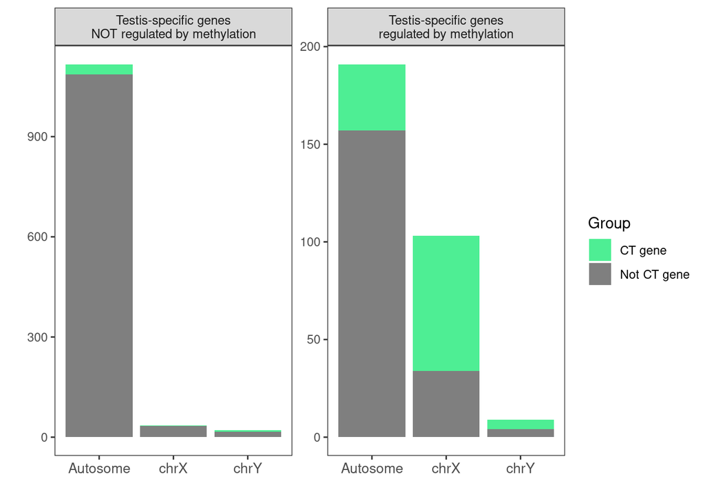

```r
fig_TS_X <- TS_genes_chr %>%
  filter(!is.na(regulated_by_methylation)) %>%
  mutate(chr = case_when(chr == "X-linked" ~ "chrX",
                         chr == "Y-linked" ~ "chrY",
                         !chr %in% c("X-linked", "Y-linked") ~ "Autosome")) %>%
  mutate(Regulation = case_when(
    regulated_by_methylation ~
      "Testis-specific genes\nregulated by methylation",
    !regulated_by_methylation ~
      "Testis-specific genes\nNOT regulated by methylation")) %>%
  mutate(Regulation =
           factor(Regulation,
                  levels =
                    c("Testis-specific genes\nNOT regulated by methylation",
                      "Testis-specific genes\nregulated by methylation"))) %>%
  mutate(Group = case_when(CT_gene_type == "CT_gene" ~ "CT gene",
                           CT_gene_type != "CT_gene" ~ "Not CT gene")) %>%
  group_by(Regulation, chr, Group) %>%
  dplyr::count() %>%
  ggplot(aes(x = chr, y = n, fill = Group)) +
  geom_col() + #width = 0.5) +
  scale_fill_manual(values = c("seagreen2", "gray50")) +
  facet_wrap(~ Regulation, scale = "free_y") +
  xlab('') +
  ylab("") +
  theme_bw() +
  theme(legend.position = "right",
        plot.title = element_text(hjust = 0.5),
        #title = element_text(size = 10, face = "bold",
        #aspect.ratio = 1.5,
        panel.grid = element_blank(),
        strip.text = element_text(size = 9),
        axis.text.x = element_text(size = 10),
        axis.title.y = element_text(size = 12))


fig_TS_X
```

## 3.5 Put figs together

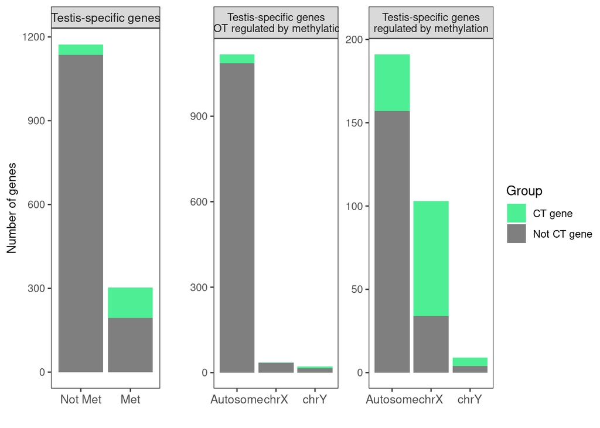

```r
fig <- cowplot::plot_grid(fig_TS_CT_genes + theme(legend.position = "none"),
                          fig_TS_X + theme(legend.position = "none"),
           rel_widths = c(1,2))


legend <- cowplot::get_legend(fig_TS_CT_genes)
cowplot::plot_grid(fig, legend, align = "v", rel_widths = c(1, 0.2))
```

```r
pdf(file = paste0("figs/Testis_specific.pdf"), width = 8, height = 4)
cowplot::plot_grid(fig, legend,
                   rel_widths = c(1, 0.2))

dev.off()
```

Putting the figs on the same panel with a bit of fine tuning

```r
x <- enframe(table(CT_genes_types$Regulation), name = "Regulation") %>%
  left_join(enframe(prop.table(table(CT_genes_types$Regulation)),
                    name = "Regulation", value = "Percent"))
```

```r
prop_fig <- ggplot(x, aes(x = '', y = value, fill = Regulation)) +
  geom_bar(stat="identity", width = 1) +
  coord_polar("y", start = 0) +
  geom_text(aes(y = value/5 + c(0, cumsum(value)[-length(value)]),
                label = rev(paste0(Regulation, "\n", value, "/",
                                   sum(table(CT_genes_types$Regulation)), "\n",
                               round(Percent * 100), "%"))), size = 1.2 )+
  scale_fill_manual(values = Regulation_colors) +
  theme(axis.title.x = element_blank(),
        axis.title.y = element_blank(),
        legend.title = element_blank(),
        panel.background = element_blank(),
        panel.border = element_blank(),
        panel.grid = element_blank(),
        axis.ticks = element_blank(),
        axis.text.x = element_blank(),
        legend.position = "none")


fig_freq_by_chr <- ggplot(CT_genes_types[
  !is.na(CT_genes_types$regulated_by_methylation), ],
  aes(x = chr, fill = Regulation)) +
  geom_bar(stat = 'count') +
  xlab("Chromosome") +
  ylab("Gene number") +
  scale_fill_manual(values = Regulation_colors) +
  theme_test()+
  theme(legend.position = "top",
        aspect.ratio = 1,
        axis.text = element_text(size = 3),
        axis.title = element_text(size = 5),
        axis.ticks = element_line(linewidth = 0.2),
        axis.ticks.length = unit(0.5, "mm"),
        legend.text = element_text(size = 5),
        legend.key.size = unit(2, "mm"),
        legend.title = element_blank())


right_fig <- cowplot::plot_grid(prop_fig, fig_freq_by_chr, fig,
                                labels = c('B', 'C', 'D'),
                                #hjust = -2,
                                vjust = 1,
                                #scale = c(0.8, 1),
                                rel_heights = c(0.5, 1),
                                ncol = 1)
```

```
## Defaulting to continuous.
```

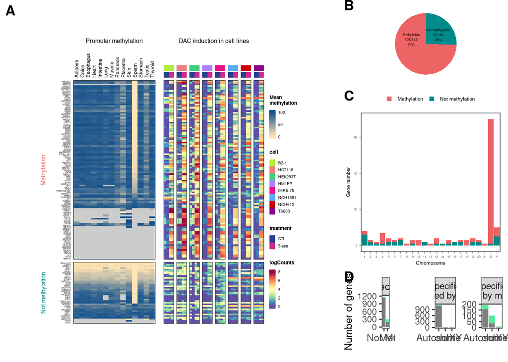

```r
left_fig <- cowplot::plot_grid(grid.grabExpr(
  draw(h_list, main_heatmap = "Mean \nmethylation", ht_gap = unit(0.3, "cm"),
       merge_legend = TRUE)), labels = c('A'))
cowplot::plot_grid(left_fig, right_fig,
          rel_widths = c(2,1),
          #scale = c(0.6, 0.5),
          label_size = 10, nrow = 1,
          #align = "h",
          align = "vh")
```

# 4 X-linked are more testis-specific than autosomal genes

```r
TS_and_TP_genes_chr <- all_genes_chr %>%
  filter(CT_gene_type %in% c("CT_gene", "CTP_gene"))
table(chr = TS_and_TP_genes_chr$chr,
      TS_and_TP_genes = TS_and_TP_genes_chr$testis_specificity)
```

```
##           TS_and_TP_genes
## chr        testis_preferential testis_specific
##   Autosome                 122              66
##   X-linked                  12              70
##   Y-linked                   0              10
```

# 5 Gene biotype

Mainly protein-coding genes Most genes are mainly protein coding genes (80.1369863%).

```r
table(Gene = CT_genes_chr$chr, CT_gene_biotype = CT_genes_chr$transcript_biotype)
```

```
##           CT_gene_biotype
## Gene       lncRNA protein_coding
##   Autosome     28             38
##   X-linked      1             69
##   Y-linked      0             10
```

```r
table(Gene = TS_genes_chr$chr, Testis_specific_genes = TS_genes_chr$transcript_biotype)
```

```
##           Testis_specific_genes
## Gene       lncRNA protein_coding
##   Autosome    937            388
##   X-linked      5            133
##   Y-linked     10             20
```

Gene biotype / regulation

```r
table(CT_genes_chr$transcript_biotype,
                 methylation = CT_genes_chr$regulated_by_methylation)
```

```
##                 methylation
##                  FALSE TRUE
##   lncRNA            13   16
##   protein_coding    24   92
```

# 6 CT genes in tumour : coexpression and link with global hypomethylation

## 6.1 Positive tumour proportion and expression level

CT genes regulated by methylation are activated more frequently and at higher levels

```r
TCGA <- TCGA_TPM
TCGA <- TCGA[, TCGA$shortLetterCode != "NT"]

tumors <- unique(TCGA$project_id)

thr_pos <- 1

prop_of_pos_tum <- as_tibble(assay(TCGA), rownames = "ensembl_gene_id") %>%
  filter(ensembl_gene_id %in% CT_genes$ensembl_gene_id) %>%
  pivot_longer(names_to = "barcode", values_to = "TPM", -ensembl_gene_id) %>%
  mutate(activated = ifelse(TPM >= thr_pos, "n_pos", "n_neg")) %>%
  group_by(ensembl_gene_id, activated) %>%
  dplyr::summarize(n = n()) %>%
  pivot_wider(names_from = activated, values_from = n) %>%
  mutate(proportion_of_positive_tum = n_pos * 100 / (n_pos + n_neg))
mean_in_pos <- as_tibble(assay(TCGA), rownames = "ensembl_gene_id") %>%
  filter(ensembl_gene_id %in% CT_genes$ensembl_gene_id) %>%
  pivot_longer(names_to = "barcode", values_to = "TPM", -ensembl_gene_id) %>%
  mutate(activated = ifelse(TPM >= thr_pos, "n_pos", "n_neg")) %>%
  filter(activated == "n_pos") %>%
  group_by(ensembl_gene_id) %>%
  summarise(mean_log = log1p(mean(TPM)),
            mean_TPM = mean(TPM))

mean_and_prop_TCGA <- prop_of_pos_tum %>%
  left_join(mean_in_pos) %>%
  right_join(CT_genes_types) %>%
  dplyr::select(gene, mean_log, proportion_of_positive_tum, Regulation,
                X_linked) %>%
  mutate(source = "TCGA tumor samples")
# combine with CCLE data
load("~/cluster/Packages/CTdata/eh_data/CCLE_data.rda")
ccle <- CCLE_data
tumors <- unique(ccle$primary_disease)

prop_of_pos_tum <- as_tibble(assay(ccle), rownames = "ensembl_gene_id") %>%
  filter(ensembl_gene_id %in% CT_genes$ensembl_gene_id) %>%
  pivot_longer(names_to = "cell", values_to = "TPM", -ensembl_gene_id) %>%
  mutate(activated = ifelse(TPM >= thr_pos, "n_pos", "n_neg")) %>%
  group_by(ensembl_gene_id, activated) %>%
  dplyr::summarize(n = n()) %>%
  pivot_wider(names_from = activated, values_from = n) %>%
  mutate(proportion_of_positive_tum = n_pos * 100 / (n_pos + n_neg))
mean_in_pos <- as_tibble(assay(ccle), rownames = "ensembl_gene_id") %>%
  filter(ensembl_gene_id %in% CT_genes$ensembl_gene_id) %>%
  pivot_longer(names_to = "cell", values_to = "TPM", -ensembl_gene_id) %>%
  mutate(activated = ifelse(TPM >= thr_pos, "n_pos", "n_neg")) %>%
  filter(activated == "n_pos") %>%
  group_by(ensembl_gene_id) %>%
  summarise(mean_log = log1p(mean(TPM)),
            mean_TPM = mean(TPM))

mean_and_prop_CCLE <- prop_of_pos_tum %>%
  left_join(mean_in_pos) %>%
  right_join(CT_genes_types) %>%
  dplyr::select(gene, mean_log, proportion_of_positive_tum, Regulation,
                X_linked) %>%
  mutate(source = "CCLE tumor cell lines")
```

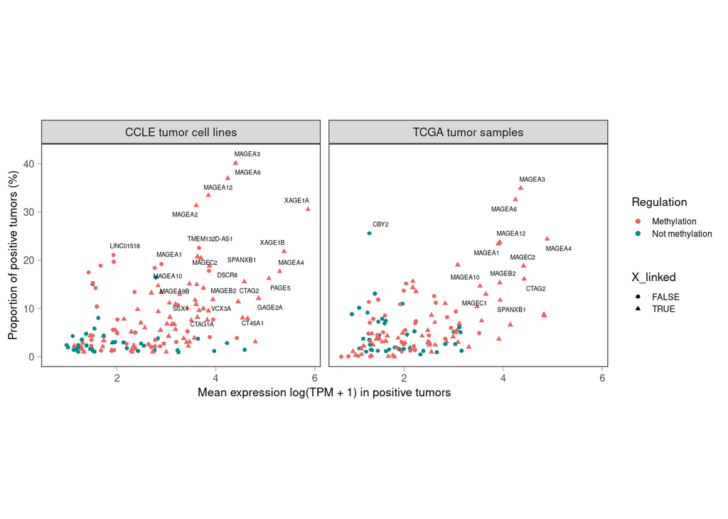

```r
mean_and_prop <- rbind(mean_and_prop_TCGA, mean_and_prop_CCLE) %>%
  filter(!is.na(Regulation))


fig_mean_prop_in_tum_horizontal <-
  ggplot(mean_and_prop,
         aes(x = mean_log, y = proportion_of_positive_tum,
             shape = X_linked,
             color = Regulation,
             label = gene)) +
  geom_point(size = 1) +
  scale_colour_manual(values = Regulation_colors)+
  ggrepel::geom_text_repel(
    data = mean_and_prop %>%
      filter(proportion_of_positive_tum > 20 |
               (proportion_of_positive_tum > 10 & mean_log > 3.5)),
    aes(x = mean_log, y = proportion_of_positive_tum,
        label = gene), size = 1.5, color = "black", min.segment.length = 4,
    max.overlaps = 30, direction = "both") +
  xlab("Mean expression log(TPM + 1) in positive tumors") +
  ylab("Proportion of positive tumors (%)") +
  facet_wrap(~ source, ncol = 2) +
  theme_bw() +
  theme(legend.position = "right",
        aspect.ratio = 0.8,
        panel.grid.major = element_blank(),
        panel.grid.minor = element_blank(),
        legend.key.size = unit(0.3, 'cm'),
        legend.text = element_text(size = 6),
        legend.title = element_text(size = 8),
        axis.text = element_text(size = 7),
        axis.ticks = element_line(size = 0.1),
        axis.title = element_text(size = 8),
        strip.text = element_text(size = 8)) +
  ylim(0,42)
fig_mean_prop_in_tum_horizontal
```

```r
# slightly modified the function
print_CCLE_heatmap <- function(genes = NULL,
                               tum_type = c("Skin", "Lung",
                                            "Colorectal",
                                            "Breast",
                                            "Head_and_Neck",
                                            "Esophageal"),
                               h_width = 5,
                               h_height = 10,
                               downsample_to_n = 450,
                               fontsize = 4,
                               clust_method = "ward.D",
                               split_rows_by = "regulation",
                               show_annotation_legend = TRUE,
                               clustRow = FALSE,
                               clustCol = TRUE){

  ## downsample tumors to have the same number of tumors in each type
  ccle <- CCLE_data
  CCLE <- ccle[, ccle$type == tum_type[1]]
  CCLE <- CCLE[, 1:min(ncol(CCLE), downsample_to_n)]

  for (tum in tum_type[-1]){
    tmp <- ccle[, ccle$type == tum]
    tmp <- tmp[, 1:min(ncol(tmp), downsample_to_n)]
    CCLE <- cbind(CCLE, tmp)
  }

  split_by <- factor(CCLE$type, levels = tum_type)

  column_ha_tumor <- HeatmapAnnotation(
    CCLE_cell_type = CCLE$type,
   # border = TRUE,
    col = list(CCLE_cell_type = CCLE_colors),
    annotation_label = gpar(fontsize = 4),
    annotation_name_gp = gpar(fontsize = 0),
    simple_anno_size = unit(0.1, "cm"),
    annotation_legend_param = legends_param)

  ## Use gene names instead of ENSEMBL IDs
  mat <- SummarizedExperiment::assay(CCLE)
  rownames(mat) <- rowData(CCLE)$external_gene_name
  mat <- log1p(mat)


  gene_type <- all_genes_clean %>%
    filter(gene %in% genes) %>%
    mutate(gene = factor(gene, levels = genes)) %>%
    arrange(gene)

 rowSplit <- NULL
  if(!is.null(split_rows_by)){
    if (split_rows_by == "regulation") {
      if (clustRow) gene_type <- gene_type %>% arrange(Regulation)
      rowSplit <- gene_type$Regulation
    }
    if (split_rows_by == "testis_specificity") {
      if (clustRow) gene_type <- gene_type %>% arrange(testis_specificity)
      rowSplit <- gene_type$testis_specificity
    }
    if (split_rows_by == "GTEX_specificity") {
      if (clustRow) gene_type <- gene_type %>% arrange(GTEX_specificity)
      rowSplit <- gene_type$GTEX_specificity
    }

    if (split_rows_by == "chr_met") {
      if (clustRow) gene_type <- gene_type %>% arrange(chr_met)
      rowSplit <- gene_type$chr_met
    }
  }

  Regulation <- as.matrix(gene_type$Regulation)
  rownames(Regulation) <- gene_type$gene
  row_ha_regulation <- rowAnnotation(Regulation = Regulation,
                                     annotation_legend_param = legends_param,
                                     simple_anno_size = unit(0.2, "cm"),
                                     col = list(Regulation = Regulation_colors),
                                     annotation_name_gp = gpar(fontsize = 0))

  chr_met <- as.matrix(gene_type$chr_met)
  rownames(chr_met) <- gene_type$gene
  row_ha_chr_met <- rowAnnotation(chr_met = chr_met,
                                  annotation_legend_param = legends_param,
                                  simple_anno_size = unit(0.2, "cm"),
                                  col = list(chr_met = chr_met_colors),
                                  annotation_name_gp = gpar(fontsize = 0))

  Chr <- as.matrix(gene_type$Chr)
  rownames(Chr) <- gene_type$gene
  row_ha_chr <- rowAnnotation(Chr = Chr,
                              annotation_legend_param = legends_param,
                              simple_anno_size = unit(0.2, "cm"),
                              col = list(Chr = Chr_colors),
                              annotation_name_gp = gpar(fontsize = 0))

  GTEX_specificity <- as.matrix(gene_type$GTEX_specificity)
  rownames(GTEX_specificity) <- gene_type$gene
  row_ha_GTEX <- rowAnnotation(GTEX_specificity = GTEX_specificity,
                             annotation_legend_param = legends_param,
                             simple_anno_size = unit(0.2, "cm"),
                             col = list(GTEX_specificity =
                                          GTEX_specificity_colors),
                             annotation_name_gp = gpar(fontsize = 0))

  testis_specificity <- as.matrix(gene_type$testis_specificity)
  rownames(testis_specificity) <- gene_type$gene
  row_ha_TS <- rowAnnotation(specificity = testis_specificity,
                             annotation_legend_param = legends_param,
                             simple_anno_size = unit(0.2, "cm"),
                             col = list(testis_specificity =
                                          Testis_specificity_colors),
                             annotation_name_gp = gpar(fontsize = 0))

  rAnnot <- NULL
  if(show_annotation_legend){
    if (split_rows_by == "regulation") {
  rAnnot <- c(row_ha_regulation, gap = unit(1, "mm"))
    }
    if (split_rows_by == "testis_specificity") {
  rAnnot <- c(row_ha_TS, gap = unit(1, "mm"))
    }
    if (split_rows_by == "GTEX_specificity") {
  rAnnot <- c(row_ha_GTEX, gap = unit(1, "mm"))
    }

    if (split_rows_by == "chr_met") {
  rAnnot <- c(row_ha_TS, gap = unit(1, "mm"))
    }
  }


  # heatmap_colors <- colorRamp2(
  #   seq(0, quantile(rowMax(mat), 0.8), length = 11),
  #   legend_colors)

  heatmap_colors <- colorRamp2(
    seq(0, 5, length = 11),
    legend_colors)

  Heatmap(mat[as.vector(gene_type$gene), ],
          name = "CCLE (logTPM)",
          #column_title = paste0("CCLE tumor cell lines"),
          column_title_gp = gpar(fontsize = 2, face = "bold"),
          clustering_method_rows = clust_method,
          clustering_method_columns = clust_method,
          column_split = split_by,
          row_gap = unit(c(0.5), "mm"),
          col = heatmap_colors,
          cluster_rows = clustRow,
          cluster_columns = clustCol,
          cluster_column_slices = FALSE,
          show_row_names = TRUE,
          show_column_names = FALSE,
          show_row_dend = FALSE,
          show_column_dend = FALSE,
          column_names_gp = gpar(fontsize = 6),
          column_names_centered = TRUE,
          row_names_gp = gpar(fontsize = fontsize),
          row_names_side = "left",
          border = TRUE,
          border_gp = gpar(lwd = 0.1),
          column_names_side = c("top"),
          column_names_rot = 90,
          row_title_gp = gpar(fontsize = 0),
          #top_annotation = column_ha_tumor,
          right_annotation = rAnnot,
          row_split = rowSplit,
          width = unit(h_width, "cm"),
          height = unit(h_height, "cm"),
          use_raster = TRUE,
          raster_device = "CairoPNG",
          raster_quality = 10,
          heatmap_legend_param = legends_param,
          show_heatmap_legend = TRUE)
}
```

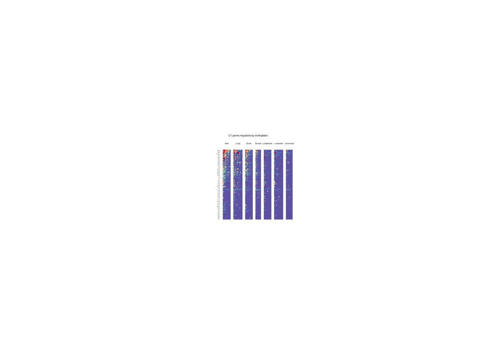

```r
met_genes <- CT_genes_types %>%
  filter(regulated_by_methylation) %>%
  pull(gene)

h1 <- print_CCLE_heatmap(met_genes,
                         downsample_to_n = 100,
                         h_width = 2.5,
                         h_height = 2.5,
                         fontsize = .5,
                         tum_type = c("Skin", "Lung",
                                      "Brain", "Breast","Lymphoma",
                                      "Leukemia", "Colorectal"),
                   clust_method = "ward.D",
                   clustRow = TRUE,
                  # show_row_names = TRUE,
                  # show_top_annotations = FALSE,
                   show_annotation_legend = FALSE,
                   split_rows_by = "regulation")
draw(h1, column_title = "CT genes regulated by methylation",
     column_title_gp = gpar(fontsize = 2.5), show_heatmap_legend = FALSE,
     show_annotation_legend = FALSE)
```

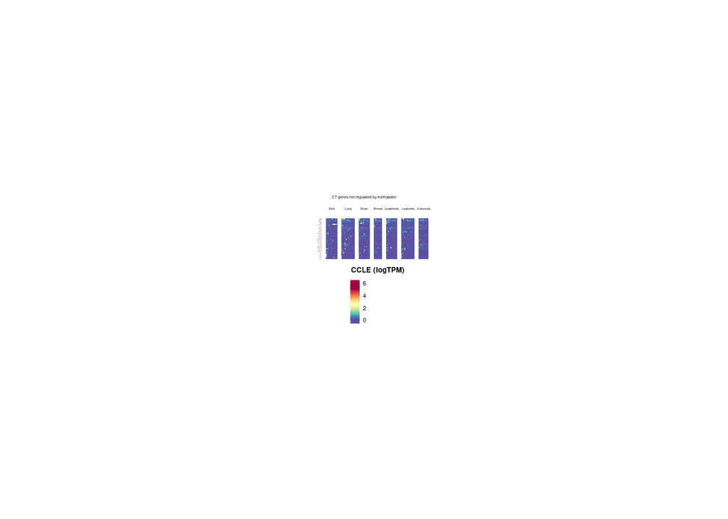

```r
not_met_genes <- CT_genes_types %>%
  filter(!regulated_by_methylation) %>%
  pull(gene)


h2 <- print_CCLE_heatmap(not_met_genes,
                         fontsize = 0.5,
                         downsample_to_n = 100,
                         h_width = 2.5,
                         h_height = 1,
                         tum_type = c("Skin", "Lung",
                                      "Brain", "Breast","Lymphoma",
                                      "Leukemia", "Colorectal"),
                         clust_method = "ward.D",
                         clustRow = TRUE,
                         show_annotation_legend = F,
                         split_rows_by = "regulation")

draw(h2, column_title = "CT genes not regulated by methylation",
     column_title_gp = gpar(fontsize = 2.5), show_heatmap_legend = TRUE,
     heatmap_legend_side = "bottom",
     show_annotation_legend = FALSE)
```

# 7 Oncogenes and Tumor suppressor

```r
onco_TS_list <- list("Tumor suppressors" = CT_genes %>%
                       filter(tumor_suppressor == "tumor_suppressor") %>%
                       pull(external_gene_name),
                     Oncogenes = CT_genes %>%
                       filter(oncogene == "oncogene") %>%
                       pull(external_gene_name))
onco_TS_list
```

```
## $`Tumor suppressors`
## [1] "LIN28A"  "SYCP1"   "CTCFL"   "TGIF2LX" "TSPY1"   "RBMY1A1"
##
## $Oncogenes
##  [1] "LIN28A"  "BRDT"    "CBY2"    "MEIOB"   "CTCFL"   "VCX"     "DDX53"
##  [8] "DCAF8L2" "SSX1"    "SSX2"    "CT45A1"  "SAGE1"   "MAGEC2"  "PASD1"
## [15] "MAGEA4"  "MAGEA3"  "MAGEA12" "MAGEA2"  "MAGEA1"  "CTAG1A"  "TSPY1"
## [22] "RBMY1A1"
```

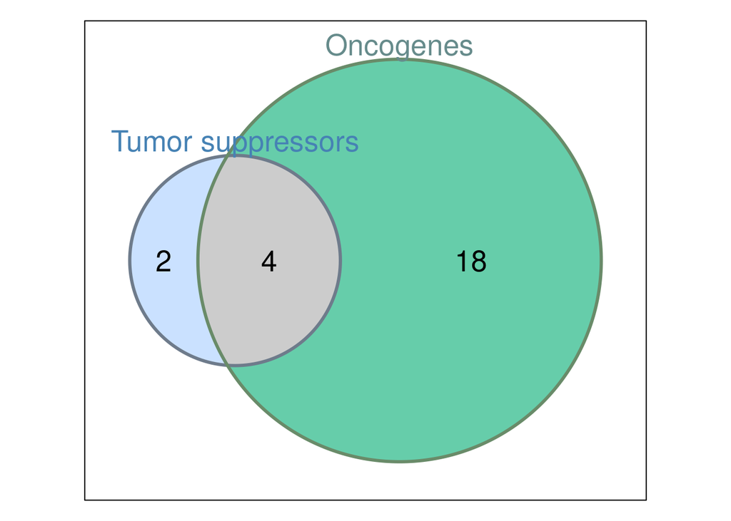

```r
gp <- VennThemes(compute.Venn(Venn(onco_TS_list)))
gp[["Face"]][["10"]]$fill <-  "lightsteelblue1"
gp[["Face"]][["01"]]$fill <-  "mediumaquamarine"
gp[["Face"]][["11"]]$fill <-  "gray80"
gp[["Set"]][["Set2"]]$col <-  "darkseagreen4"
gp[["Set"]][["Set1"]]$col <-  "lightsteelblue4"
gp[["SetText"]][["Set1"]]$col <-  "steelblue"
gp[["SetText"]][["Set2"]]$col <-  "paleturquoise4"
gp[["FaceText"]][["10"]]$col <-  "black"
plot(Vennerable::Venn(onco_TS_list), gp = gp)
```

# 8 CT expression in healthy cells (fetal and adult)

## 8.1 Heatmap

First treating data

```r
# Missing genes are probably just not detected
# Add zero counts to  missing genes in all datasets

testis_sce <- testis_sce[CT_genes$external_gene_name[
  CT_genes$external_gene_name %in% rownames(testis_sce)],]


# add missing CT genes (not in the downloaded dataset, as not detected
# (below detection) => were removed)
# Add zero count values for these genes
rowData(testis_sce) <- NULL
missing_CT <- CT_genes$external_gene_name[!CT_genes$external_gene_name %in%
                                            rownames(testis_sce)]
missing_CT
```

```
##  [1] "KAZN-AS1"    "NFIA-AS1"    "LRRC52-AS1"  "ZC3H11B"     "THORLNC"
##  [6] "LINC02377"   "SLC7A11-AS1" "LINC02241"   "LINC02228"   "LINC03004"
## [11] "SEC61G-DT"   "ZNF722"      "GTF2I-AS1"   "SPATA31C2"   "TEX48"
## [16] "LINC02663"   "LINC02750"   "FAM230C"     "GOLGA6L7"    "LINC02864"
## [21] "ZNF723"      "PPP4R3C"     "CENPVL2"     "CENPVL1"     "CT47A1"
## [26] "CT45A6"      "CT45A7"      "CT45A8"      "CT45A9"      "MAGEA4-AS1"
## [31] "MAGEA2"      "VCY"         "VCY1B"       "RBMY1B"
```

```r
sce_missing_CT <- testis_sce[1:length(missing_CT),]
rownames(sce_missing_CT) <- missing_CT
count_mat_missing_CT <- matrix(nrow = length(missing_CT),
                               ncol = ncol(testis_sce), data = 0)
rownames(count_mat_missing_CT) <- missing_CT
colnames(count_mat_missing_CT) <- colnames(testis_sce)
assay(sce_missing_CT,1) <- count_mat_missing_CT
assay(sce_missing_CT,2) <- count_mat_missing_CT
testis_sce <- rbind(testis_sce, sce_missing_CT)


# add missing CT genes (not in the downloaded dataset, as not detected
# (below detection) => were removed)
# Add zero count values for these genes
rowData(FGC_sce) <- NULL

FGC_sce <- FGC_sce[CT_genes$external_gene_name[
  CT_genes$external_gene_name %in% rownames(FGC_sce)],]

missing_CT <- CT_genes$external_gene_name[!CT_genes$external_gene_name %in%
                                            rownames(FGC_sce)]
sce_missing_CT <- FGC_sce[1:length(missing_CT),]
rownames(sce_missing_CT) <- missing_CT
count_mat_missing_CT <- matrix(nrow = length(missing_CT),
                               ncol = ncol(FGC_sce), data = 0)
rownames(count_mat_missing_CT) <- missing_CT
colnames(count_mat_missing_CT) <- colnames(FGC_sce)
assay(sce_missing_CT,1) <- count_mat_missing_CT
assay(sce_missing_CT,2) <- count_mat_missing_CT
FGC_sce <- rbind(FGC_sce, sce_missing_CT)


# add missing CT genes (not in the downloaded dataset, as not detected (below
# detection) => were removed)
# Add zero count values for these genes
rowData(oocytes_sce) <- NULL
oocytes_sce <- oocytes_sce[CT_genes$external_gene_name[
  CT_genes$external_gene_name %in% rownames(oocytes_sce)],]
missing_CT <- CT_genes$external_gene_name[!CT_genes$external_gene_name %in%
                                            rownames(oocytes_sce)]
sce_missing_CT <- oocytes_sce[1:length(missing_CT),]
rownames(sce_missing_CT) <- missing_CT
count_mat_missing_CT <- matrix(nrow = length(missing_CT),
                               ncol = ncol(oocytes_sce), data = 0)
rownames(count_mat_missing_CT) <- missing_CT
colnames(count_mat_missing_CT) <- colnames(oocytes_sce)
assay(sce_missing_CT,1) <- count_mat_missing_CT
assay(sce_missing_CT,2) <- count_mat_missing_CT
oocytes_sce <- rbind(oocytes_sce, sce_missing_CT)



# pool Sperm1 and Sperm2 types
levels(testis_sce$type)[c(7,8)] <- "Sperm"
germcells <-  c("SSC", "Spermatogonia", "Early_spermatocyte",
                "Late_spermatocyte", "Round_spermatid",
                "Elongated_spermatid", "Sperm")

# add meiotic stage to the colData of testis_sce
testis_sce$stage <- "pre-meiotic"
testis_sce[, testis_sce$type %in%
             c("Early_spermatocyte", "Late_spermatocyte")]$stage <- "meiotic"
testis_sce[, testis_sce$type %in%
             c("Round_spermatid", "Elongated_spermatid", "Sperm")]$stage <-
  "post-meiotic"
testis_sce[, testis_sce$type %in%
             c("Macrophage", "Endothelial", "Myoid", "Sertoli",
               "Leydig")]$stage <- "somatic"
testis_sce$stage <- factor(
  testis_sce$stage,
  levels = c("pre-meiotic", "meiotic", "post-meiotic", "somatic"))


# Remove genes with rowcounts = 0 in all datasets
# !!! Few genes are not detetected in testis_Sce but in FGC or oocytes
not_in_testis_sce <- rownames(testis_sce)[rowSums(assay(testis_sce)) == 0]
not_in_FGC_sce <- rownames(FGC_sce)[rowSums(assay(FGC_sce)) == 0]
not_in_oocytes_sce <- rownames(oocytes_sce)[rowSums(assay(oocytes_sce)) == 0]
not_in_testis_FGC <- BiocGenerics::intersect(not_in_testis_sce, not_in_FGC_sce)
not_in_testis_FGC_oocytes <- BiocGenerics::intersect(not_in_testis_FGC,
                                                     not_in_oocytes_sce)

kept_genes <- CT_genes %>%
  filter(!is.na(regulated_by_methylation)) %>%
  filter(!external_gene_name %in% not_in_testis_FGC_oocytes) %>%
  pull(external_gene_name)

never <- CT_genes %>%
  filter(!is.na(regulated_by_methylation)) %>%
  filter(external_gene_name %in% not_in_testis_FGC_oocytes) %>%
  pull(external_gene_name)

legends_param <- list(
  labels_gp = gpar(col = "black", fontsize = 2),
  title_gp = gpar(col = "black", fontsize = 3),
  simple_anno_size = unit(0.15, "cm"),
  row_names_gp = gpar(fontsize = 1),
  annotation_name_side = "left",
  border = FALSE,
  border_gp = gpar(lwd = 0.01),
  grid_width = unit(0.2, "cm"),
  grid_height = unit(0.2, "cm"),
  legend_height = unit(0.1, "cm"),
  annotation_name_gp = gpar(fontsize = 0))

# To label Y linked genes on the heatmaps
CT_genes_types <- CT_genes_types %>%
  mutate(chromosome = case_when(chr == "X" ~ "X-linked",
                                chr == "Y" ~ "Y-linked",
                                !chr %in% c("X", "Y") ~ "Autosome"))
table(CT_genes_types$chromosome)
```

```
##
## Autosome X-linked Y-linked
##       66       70       10
```

Kept 135 CT genes for the analysis:

CT genes with logcounts >= 0 in at least one of the dataset

```r
# Function to downsample cell types

sample_cells <- function(barcodes, nmax){
  sample(barcodes, size = min(nmax, length(barcodes)), replace = FALSE)
}


## Function to draw expression in FGC with specific annotations
## and downasampling the number of cells from each cell type

draw_FGC_heatmap <- function(genes,
                             split_by = "chr_met",
                             ncells_max = NULL,
                             cell_type = NULL,
                             scale_lims = NULL,
                             sex = c("F", "M"),
                             clusterRow = FALSE,
                             font_size = 6,
                             show_legend = TRUE,
                             h_width = 5,
                             h_height = 10,
                             show_right_annot = TRUE){

  fetal_sce <- FGC_sce

  if (!is.null(cell_type)) fetal_sce <- fetal_sce[,FGC_sce$type %in% cell_type]

  # Set the colors used in the final heatmap based on all samples (F + M),
  # even when representing only F or M samples on the heatmap
  # => same scale of colors
  mat <-  as.matrix(assay(fetal_sce, "logcounts")[genes, ])

  if (is.null(scale_lims)) {
    scale_lims <- c(0, quantile(rowMaxs(mat), 0.8))
  }

  heatmap_colors <- colorRamp2(
    seq(scale_lims[1], scale_lims[2], length = 11),
    legend_colors)

  fetal_sce <- fetal_sce[, fetal_sce$sex %in% sex]

  df_col_FCS <- data.frame(development_stage = fetal_sce$development_stage,
                           sex = fetal_sce$sex,
                           stage = fetal_sce$stage,
                           donor_id = fetal_sce$donor_id,
                           fetal_cell_type = fetal_sce$cell_type,
                           type = fetal_sce$type)

  rownames(df_col_FCS) <- colnames(fetal_sce)
  df_col_FCS <- df_col_FCS[order(df_col_FCS$type),]

  #Randomly pick ncells_max cells of each cell type
  if (!is.null(ncells_max)) {
    set.seed(123)
    selected_cells <- sample_cells(
      rownames(df_col_FCS[df_col_FCS$type == levels(df_col_FCS$type)[1],]),
      ncells_max)
    for (type in levels(df_col_FCS$type)[-1]){
      tmp <- sample_cells(
        rownames(df_col_FCS[df_col_FCS$type == type,]), ncells_max)
      selected_cells <- c(selected_cells, tmp)
    }
    df_col_FCS <- df_col_FCS[selected_cells,]
  }

  column_ha_type = HeatmapAnnotation(
    Fetal_cell_type = df_col_FCS$type,
    col = list(Fetal_cell_type = Fetal_cell_colors),
    border = TRUE,
    simple_anno_size = unit(0.15, "cm"),
    annotation_legend_param = legends_param,
    annotation_name_gp = gpar(fontsize = 0))

  column_ha_development_stage = HeatmapAnnotation(
    development_stage = df_col_FCS$development_stage,
    border = TRUE,
    simple_anno_size = unit(0.15, "cm"),
    annotation_legend_param = legends_param,
    annotation_name_gp = gpar(fontsize = 0))

  column_ha_sex = HeatmapAnnotation(
    sex = df_col_FCS$sex,
    col = list(sex = sex_colors),
    border = TRUE,
    simple_anno_size = unit(0.15, "cm"),
    annotation_legend_param = legends_param,
    annotation_name_gp = gpar(fontsize = 0))

  column_ha_donor_id = HeatmapAnnotation(
    donor_id = df_col_FCS$donor_id,
    border = TRUE,
    simple_anno_size = unit(0.15, "cm"),
    annotation_legend_param = legends_param,
    annotation_name_gp = gpar(fontsize = 0))

  column_ha_stage = HeatmapAnnotation(
    stage = df_col_FCS$stage,
    col = list(stage = stage_colors),
    border = TRUE,
    simple_anno_size = unit(0.15, "cm"),
    annotation_legend_param = legends_param,
    annotation_name_gp = gpar(fontsize = 0))

  gene_type <- CT_genes_types %>%
    filter(gene %in% genes)

  if (split_by == "regulation") {
    gene_type <- gene_type %>% arrange(Regulation)
    rowSplit <- gene_type$Regulation
  }
  if (split_by == "testis_specificity") {
    gene_type <- gene_type %>% arrange(Testis_specificity)
    rowSplit <- gene_type$Testis_specificity
  }
  if (split_by == "chr_met") {
    gene_type <- gene_type %>% arrange(chr_met)
    rowSplit <- gene_type$chr_met
  }
  if (!clusterRow & split_by == "chr_met") {
    gene_type$gene <- factor(gene_type$gene, levels = genes)
    gene_type <- gene_type  %>%
      arrange(gene)
    gene_type$gene <- as.vector(gene_type$gene)
    rowSplit <- gene_type$chr_met
  }
  if (split_by == "met_3_groups") {
    gene_type <- gene_type %>% arrange(met_3_groups)
    rowSplit <- gene_type$met_3_groups
  }
   if (!clusterRow & split_by == "met_3_groups") {
    gene_type$gene <- factor(gene_type$gene, levels = genes)
    gene_type <- gene_type  %>%
      arrange(gene)
    gene_type$gene <- as.vector(gene_type$gene)
    rowSplit <- gene_type$met_3_groups
   }

  Regulation <- as.matrix(gene_type$Regulation)
  rownames(Regulation) <- gene_type$gene
  row_ha_regulation <- rowAnnotation(
    Regulation = Regulation,
    annotation_legend_param = legends_param,
    border = FALSE,
    simple_anno_size = unit(0.15, "cm"),
    col = list(Regulation = Regulation_colors),
    annotation_name_gp = gpar(fontsize = 0))

  chr_met <- as.matrix(gene_type$chr_met)
  rownames(chr_met) <- gene_type$gene
  row_ha_chr_met <- rowAnnotation(
    chr_met = chr_met,
    annotation_legend_param = legends_param,
    border = FALSE,
    simple_anno_size = unit(0.15, "cm"),
    col = list(chr_met = chr_met_colors),
    annotation_name_gp = gpar(fontsize = 0))

  Chr <- as.matrix(gene_type$chromosome)
  rownames(Chr) <- gene_type$gene
  row_ha_chr <- rowAnnotation(Chr = Chr,
                              annotation_legend_param = legends_param,
                              border = FALSE,
                              simple_anno_size = unit(0.15, "cm"),
                              col = list(Chr = Chr_colors_with_Y),
                              annotation_name_gp = gpar(fontsize = 0))

  mat <- as.matrix(
    assay(fetal_sce, "logcounts")[gene_type$gene, rownames(df_col_FCS)])

  rAnnot <- c(row_ha_regulation, row_ha_chr, gap = unit(1, "mm"))

  if (!show_right_annot) rAnnot <- NULL
```

```r
  title <- "Fetal germ cells"
  if (all(sex == "F")) {
    title <- "Female fetal germ cells"
  }
  if (all(sex == "M")) {
    title <- "Male fetal germ cells"
  }

  if (is.null(scale_lims)) {
    scale_lims <- c(0, quantile(rowMaxs(mat), 0.8))
  }

  heatmap_colors <- colorRamp2(
    seq(scale_lims[1], scale_lims[2], length = 11),
    legend_colors)

  ht_FGCs <- Heatmap(mat,
                     name = "Logcounts",
                     column_title = title,
                     column_split = df_col_FCS$type,
                     cluster_row_slices = FALSE,
                     cluster_column_slices = FALSE,
                     col = heatmap_colors,
                     border = TRUE,
                     border_gp = gpar(lwd = 0.2),
                     row_gap = unit(c(1), "mm"),
                     column_gap = unit(c(0.5), "mm"),
                     show_column_dend = FALSE,
                     show_row_dend = FALSE,
                     row_names_gp = gpar(fontsize = font_size),
                     row_names_side = "left",
                     cluster_rows = clusterRow,
                     cluster_columns = FALSE,
                     show_column_names = FALSE,
                     show_row_names = TRUE,
                     row_split = rowSplit,
                     top_annotation = c(column_ha_sex,
                                        column_ha_stage,
                                        #column_ha_group,
                                        #column_ha_donor_id,
                                        column_ha_type),
                     right_annotation = rAnnot,
                     column_title_gp = gpar(fontsize = 5),
                     row_title_gp = gpar(fontsize = 0),
                     gap = unit(0.01, "mm"),
                     use_raster = TRUE,
                     raster_device = "CairoPNG",
                     #heatmap_width = unit(h_width, "cm"),
                     #heatmap_height = unit(h_height, "cm"),
                     raster_quality = 10,
                     show_heatmap_legend = show_legend,
                     heatmap_legend_param = legends_param)

  return(ht_FGCs)
}


## Function to draw expression in adult testis cells with specific annotations
## and downasampling the number of cells from each cell type

draw_testis_heatmap <- function(genes,
                                split_by = "chr_met",
                                sex = c("F", "M"),
                                ncells_max = NULL,
                                font_size = 6,
                                scale_lims = NULL,
                                clusterRow = FALSE,
                                show_legend = TRUE,
                                h_width = 5,
                                h_height = 10,
                                clust_method = "ward.D"){

  testis_adult_sce <- testis_sce[, testis_sce$stage != "somatic"]
  testis_adult_sce$type <- factor(testis_adult_sce$type, levels = germcells)
  testis_adult_sce$stage <- factor(testis_adult_sce$stage,
                                   levels = c("pre-meiotic", "meiotic",
                                              "post-meiotic"))
  df_col_testis <- data.frame(type = testis_adult_sce$type,
                              donor = testis_adult_sce$Donor,
                              stage = testis_adult_sce$stage)

  df_col_testis$sex <- "M"

  rownames(df_col_testis) <- colnames(testis_adult_sce)
  df_col_testis <- df_col_testis[order(df_col_testis$type),]

  #Randomly pick ncells_max cells of each cell type
  if (!is.null(ncells_max)) {
    set.seed(123)
    selected_cells <- sample_cells(
      rownames(df_col_testis[df_col_testis$type ==
                               levels(df_col_testis$type)[1],]), ncells_max)
    for (type in levels(df_col_testis$type)[-1]){
      tmp <- sample_cells(
        rownames(df_col_testis[df_col_testis$type == type,]), ncells_max)
      selected_cells <- c(selected_cells, tmp)
    }
    df_col_testis <- df_col_testis[selected_cells,]
  }

  column_ha_cell_type = HeatmapAnnotation(
    Testis_cell_type = df_col_testis$type,
    col = list(Testis_cell_type = testis_colors),
    annotation_legend_param = legends_param,
    border = TRUE,
    simple_anno_size = unit(0.15, "cm"),
    annotation_name_gp = gpar(fontsize = 0))

  column_ha_stage = HeatmapAnnotation(
    stage = df_col_testis$stage,
    col = list(stage = stage_colors),
    annotation_legend_param = legends_param,
    border = TRUE,
    simple_anno_size = unit(0.15, "cm"),
    annotation_name_gp = gpar(fontsize = 0))

  column_ha_sex = HeatmapAnnotation(
    sex = df_col_testis$sex,
    col = list(sex = sex_colors),
    annotation_legend_param = legends_param,
    border = TRUE,
    simple_anno_size = unit(0.15, "cm"),
    annotation_name_gp = gpar(fontsize = 0))

  gene_type <- CT_genes_types %>%
    filter(gene %in% genes)

  if (split_by == "regulation") {
    gene_type <- gene_type %>% arrange(Regulation)
    rowSplit <- gene_type$Regulation
  }
  if (split_by == "testis_specificity") {
    gene_type <- gene_type %>% arrange(Testis_specificity)
    rowSplit <- gene_type$Testis_specificity
  }
  if (split_by == "chr_met") {
    gene_type <- gene_type %>% arrange(chr_met)
    rowSplit <- gene_type$chr_met
  }
  if (!clusterRow & split_by == "chr_met") {
    gene_type$gene <- factor(gene_type$gene, levels = genes)
    gene_type <- gene_type  %>%
      arrange(gene)
    gene_type$gene <- as.vector(gene_type$gene)
    rowSplit <- gene_type$chr_met
  }

  if (split_by == "met_3_groups") {
    gene_type <- gene_type %>% arrange(met_3_groups)
    rowSplit <- gene_type$met_3_groups
  }
  if (!clusterRow & split_by == "met_3_groups") {
    gene_type$gene <- factor(gene_type$gene, levels = genes)
    gene_type <- gene_type  %>%
      arrange(gene)
    gene_type$gene <- as.vector(gene_type$gene)
    rowSplit <- gene_type$met_3_groups
  }

  Regulation <- as.matrix(gene_type$Regulation)
  rownames(Regulation) <- gene_type$gene
  row_ha_regulation <- rowAnnotation(
    Regulation = Regulation,
    annotation_legend_param = legends_param,
    border = FALSE,
    simple_anno_size = unit(0.15, "cm"),
    col = list(Regulation = Regulation_colors),
    annotation_name_gp = gpar(fontsize = 0))
```

```r
  chr_met <- as.matrix(gene_type$chr_met)
  rownames(chr_met) <- gene_type$gene
  row_ha_chr_met <- rowAnnotation(
    chr_met = chr_met,
    annotation_legend_param = legends_param,
    border = FALSE,
    simple_anno_size = unit(0.15, "cm"),
    col = list(chr_met = chr_met_colors),
    annotation_name_gp = gpar(fontsize = 0))

  Chr <- as.matrix(gene_type$chromosome)
  rownames(Chr) <- gene_type$gene
  row_ha_chr <- rowAnnotation(Chr = Chr,
                              annotation_legend_param = legends_param,
                              border = FALSE,
                              simple_anno_size = unit(0.15, "cm"),
                              col = list(Chr = Chr_colors_with_Y),
                              annotation_name_gp = gpar(fontsize = 0))

  mat <-  as.matrix(
    assay(testis_adult_sce, "logcounts")[gene_type$gene, rownames(df_col_testis)])

  if (is.null(scale_lims)) {
    scale_lims <- c(0, quantile(rowMaxs(mat), 0.8))
  }

  heatmap_colors <- colorRamp2(
    seq(scale_lims[1], scale_lims[2], length = 11),
    legend_colors)

  ht_testis <- Heatmap(mat,
                       name = "logcounts",
                       column_title = "Adult testis",
                       column_split = df_col_testis$type,
                       row_title = NULL,
                       col = heatmap_colors,
                       border = TRUE,
                       border_gp = gpar(lwd = 0.2),
                       row_gap = unit(c(0.5), "mm"),
                       column_gap = unit(c(0.5), "mm"),
                       show_column_dend = FALSE,
                       show_row_dend = FALSE,
                       row_names_gp = gpar(fontsize = font_size),
                       row_names_side = "right",
                       cluster_rows = clusterRow,
                       clustering_method_rows = clust_method,
                       row_dend_reorder = TRUE,
                       cluster_columns = FALSE,
                       show_column_names = FALSE,
                       show_row_names = FALSE,
                       row_split = rowSplit,
                       cluster_row_slices = FALSE,
                       cluster_column_slices = FALSE,
                       top_annotation = c(column_ha_sex,
                                          column_ha_stage,
                                          column_ha_cell_type),
                       right_annotation = c(row_ha_regulation,
                                            row_ha_chr,
                                            gap = unit(1, "mm")),
                       column_title_gp = gpar(fontsize = 5),
                       row_title_gp = gpar(fontsize = 0),
                       gap = unit(0.01, "mm"),
                       use_raster = TRUE,
                       raster_device = "CairoPNG",
                       raster_quality = 10,
                       #heatmap_width = unit(h_width, "cm"),
                       #heatmap_height = unit(h_height, "cm"),
                       show_heatmap_legend =  show_legend,
                       heatmap_legend_param = legends_param)

  return(ht_testis)
}

## Function to draw expression in adult oocytes cells with specific annotations
## and downasampling the number of cells from each cell type

draw_oocytes_heatmap <- function(genes,
                                 split_by = "chr_met",
                                 ncells_max = NULL,
                                 font_size = 6,
                                 scale_lims = NULL,
                                 clusterRow = TRUE,
                                 show_legend = TRUE,
                                 h_width = 5,
                                 h_height = 10,
                                 clust_method = "ward.D"){

  adult_oocytes_sce <- oocytes_sce[, oocytes_sce$type %in% c("Growing oocytes",
                                                             #"Fully grown oocytes",
                                                             #"Metaphase I",
                                                             "Metaphase II")]

  df_col_oocytes <- data.frame(type = adult_oocytes_sce$type,
                               sex = adult_oocytes_sce$sex,
                               stage = adult_oocytes_sce$stage)

  rownames(df_col_oocytes) <- colnames(adult_oocytes_sce)
  df_col_oocytes <- df_col_oocytes[order(df_col_oocytes$type),]

  #Randomly pick ncells_max cells of each cell type
  if (!is.null(ncells_max)) {
    set.seed(123)
    selected_cells <- sample_cells(
      rownames(df_col_oocytes[df_col_oocytes$type ==
                                levels(df_col_oocytes$type)[1],]), ncells_max)
    for (type in levels(df_col_oocytes$type)[-1]){
      tmp <- sample_cells(
        rownames(df_col_oocytes[df_col_oocytes$type == type,]), ncells_max)
      selected_cells <- c(selected_cells, tmp)
    }
    df_col_oocytes <- df_col_oocytes[selected_cells,]
  }

  column_ha_cell_type = HeatmapAnnotation(
    Oocytes_cell_type = df_col_oocytes$type,
    col = list(Oocytes_cell_type = oocytes_colors),
    border = TRUE,
    simple_anno_size = unit(0.15, "cm"),
    annotation_name_gp = gpar(fontsize = 0),
    annotation_legend_param = legends_param)

  column_ha_stage = HeatmapAnnotation(
    stage = df_col_oocytes$stage,
    col = list(stage = stage_colors),
    border = TRUE,
    simple_anno_size = unit(0.15, "cm"),
    annotation_legend_param = legends_param,
    annotation_name_gp = gpar(fontsize = 0))

  column_ha_sex = HeatmapAnnotation(
    sex = df_col_oocytes$sex,
    col = list(sex = sex_colors),
    annotation_legend_param = legends_param,
    border = TRUE,
    simple_anno_size = unit(0.15, "cm"),
    annotation_name_gp = gpar(fontsize = 0))

  gene_type <- CT_genes_types %>%
    filter(gene %in% genes)

  if (split_by == "regulation") {
    gene_type <- gene_type %>% arrange(Regulation)
    rowSplit <- gene_type$Regulation
  }
  if (split_by == "testis_specificity") {
    gene_type <- gene_type %>% arrange(Testis_specificity)
    rowSplit <- gene_type$Testis_specificity
  }
  if (split_by == "chr_met") {
    gene_type <- gene_type %>% arrange(chr_met)
    rowSplit <- gene_type$chr_met
  }
  if (!clusterRow & split_by == "chr_met") {
    gene_type$gene <- factor(gene_type$gene, levels = genes)
    gene_type <- gene_type  %>%
      arrange(gene)
    gene_type$gene <- as.vector(gene_type$gene)
    rowSplit <- gene_type$chr_met
  }
  if (split_by == "met_3_groups") {
    gene_type <- gene_type %>% arrange(met_3_groups)
    rowSplit <- gene_type$met_3_groups
  }
  if (!clusterRow & split_by == "met_3_groups") {
    gene_type$gene <- factor(gene_type$gene, levels = genes)
    gene_type <- gene_type  %>%
      arrange(gene)
    gene_type$gene <- as.vector(gene_type$gene)
    rowSplit <- gene_type$met_3_groups
  }
```

```r
  Regulation <- as.matrix(gene_type$Regulation)
  rownames(Regulation) <- gene_type$gene
  row_ha_regulation <- rowAnnotation(
    Regulation = Regulation,
    annotation_legend_param = legends_param,
    border = FALSE,
    simple_anno_size = unit(0.15, "cm"),
    col = list(Regulation = Regulation_colors),
    annotation_name_gp = gpar(fontsize = 0))

  chr_met <- as.matrix(gene_type$chr_met)
  rownames(chr_met) <- gene_type$gene
  row_ha_chr_met <- rowAnnotation(
    chr_met = chr_met,
    annotation_legend_param = legends_param,
    border = FALSE,
    simple_anno_size = unit(0.15, "cm"),
    col = list(chr_met = chr_met_colors),
    annotation_name_gp = gpar(fontsize = 0))

  Chr <- as.matrix(gene_type$chromosome)
  rownames(Chr) <- gene_type$gene
  row_ha_chr <- rowAnnotation(Chr = Chr,
                              annotation_legend_param = legends_param,
                              border = FALSE,
                              simple_anno_size = unit(0.15, "cm"),
                              col = list(Chr = Chr_colors_with_Y),
                              annotation_name_gp = gpar(fontsize = 0))

  mat <-  as.matrix(
    assay(adult_oocytes_sce, "logcounts")[gene_type$gene, rownames(df_col_oocytes)])

  if (is.null(scale_lims)) {
    scale_lims <- c(0, quantile(rowMaxs(mat), 0.8))
  }

  heatmap_colors <- colorRamp2(
    seq(scale_lims[1], scale_lims[2], length = 11),
    legend_colors)

  ht_oocytes <- Heatmap(mat,
                        name = "oocytes logcounts",
                        column_title = "Adult oocytes",
                        column_split = df_col_oocytes$type,
                        col = heatmap_colors,
                        border = TRUE,
                        border_gp = gpar(lwd = 0.2),
                        row_gap = unit(c(0.5), "mm"),
                        column_gap = unit(c(0.5), "mm"),
                        show_column_dend = FALSE,
                        show_row_dend = FALSE,
                        row_names_gp = gpar(fontsize = font_size),
                        row_names_side = "left",
                        cluster_rows = clusterRow,
                        clustering_method_rows = clust_method,
                        row_dend_reorder = TRUE,
                        cluster_columns = FALSE,
                        show_column_names = FALSE,
                        show_row_names = TRUE,
                        row_split = rowSplit,
                        cluster_row_slices = FALSE,
                        cluster_column_slices = FALSE,
                        top_annotation = c(column_ha_sex,
                                           column_ha_stage,
                                           column_ha_cell_type),
                        # right_annotation = c(row_ha_regulation,
                        #                      row_ha_chr,
                        #                      gap = unit(1, "mm")),
                        column_title_gp = gpar(fontsize = 5),
                        row_title_gp = gpar(fontsize = 0),
                        gap = unit(0.01, "mm"),
                        use_raster = TRUE,
                        raster_device = "CairoPNG",
                        raster_quality = 10,
                        #heatmap_width = unit(h_width, "cm"),
                        #heatmap_height = unit(h_height, "cm"),
                        show_heatmap_legend = show_legend,
                        heatmap_legend_param = legends_param)

  return(ht_oocytes)
}
```

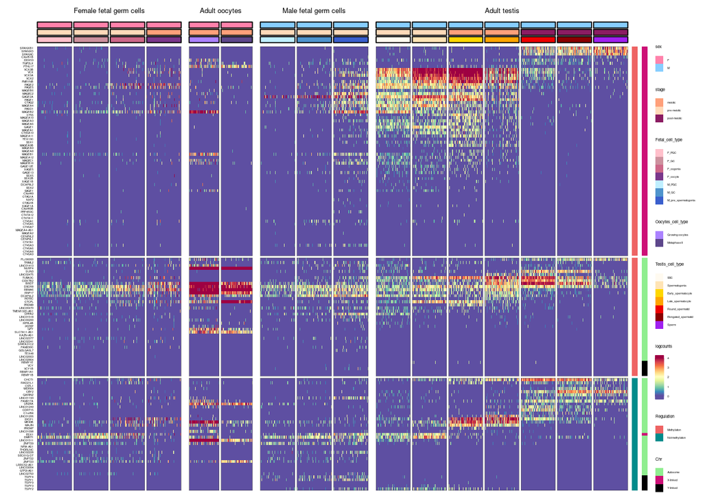

```r
# Manual adjustments to visualise
X_met_new_order <-
  c("SPANXB1", "SPANXD", "SPANXC",  "CXorf51B", "DDX53",
    "TGIF2LX", "FTHL17","VCX3B", "VCX", "VCX3A", "VCX2", "FMR1NB",  "PAGE2",
    "PAGE5", "MAGEB6", "MAGEC2","GAGE2A","PAGE1",  "CTAG2",  "MAGEA4",
    "PASD1","MAGEB2","CT55","MAGEA10",  "MAGEA3",  "MAGEA6","GAGE1", "MAGEA1",
    "CT45A10", "MAGEA11", "TEX13C", "SSX1", "MAGEA9B","MAGEA9", "MAGEA8",
    "MAGEB1", "MAGEA12", "MAGEC1", "MAGEB16","GAGE12E",  "XAGE5", "GAGE13",
    "SSX5",  "SSX2B", "XAGE1B",  "DCAF8L2", "SSX2", "SAGE1",
    "CXorf49", "CTAG1A", "NXF2",  "CTAG1B", "XAGE1A",
    "CXorf49B","PPP4R3C", "CT47A12",
    "CT47A11", "CT45A1","CT45A5","CT45A7", "MAGEA4-AS1", "MAGEA2",
      "CENPVL2", "CENPVL1", "CT47A1",  "CT45A3",  "CT45A6", "CT45A8", "CT45A9")

not_X_met_new_order <-
  c( "FLJ36000", "TRIML2", "LINC01413", "NLRP4", "SUN3",
    "LINC02475",  "TUBA3C", "COX7B2",
     "BRDT", "DSCR8",  "RBM46", "RNF17", "DCAF4L2",
     "POTEC","CTCFL", "PRDM9",  "LINC00470",
    "TMEM132D-AS1", "DPPA2",
     "LINC01518", "LINC00200", "RFPL4B", "POTEF",
      "GFY", "SLC7A11-AS1",
    "KAZN-AS1", "LINC02377",    "LINC02241",   "SPATA31C2",
    "FAM230C", "GOLGA6L7", "TEX48", "LINC02663", "LINC02864",
    "RBMY1E", "VCY", "VCY1B", "RBMY1A1","RBMY1B"   )


not_met_new_order <-
  c("CHCT1", "RAD21L1", "CSTL1", "WDR64", "CBY2", "GARIN2","LINC01193",
    "FAM217A", "LIN28A", "LINC01249",
    "CDRT15","C1orf94", "LINC01206", "SYCP1", "MEIOB", "MAJIN",
    "PRDM7",  "LINC01098", "ESX1", "DMRT1", "LINC01511", "ZNF729",
    "NFIA-AS1", "THORLNC", "LINC02228", "SEC61G-DT", "ZNF722",  "ZNF723",
    "LRRC52-AS1",

     "LINC03004",
    "GTF2I-AS1", "LINC02750",  "TSPY4", "TSPY1", "TSPY9", "TSPY3", "TSPY2")


my_genes <- c(X_met_new_order, not_X_met_new_order, not_met_new_order)


fs <- 2
scale_limits <- c(0, 4)
ncells <- 100
ht_testis <- draw_testis_heatmap(my_genes,
                                 ncells_max = ncells,
                                 font_size = fs,
                                 scale_lims = scale_limits,
                                 clusterRow  = FALSE,
                                 split_by = "met_3_groups",
                                 show_legend = TRUE,
                                 clust_method = "ward.D2")

female_FGC_ht <- draw_FGC_heatmap(my_genes,
                                  ncells_max = ncells,
                                  sex = c("F"),
                                  clusterRow = FALSE,
                                  font_size = fs,
                                  scale_lims = scale_limits,
                                  show_legend = FALSE,
                                  show_right_annot = FALSE)

male_FGC_ht <- draw_FGC_heatmap(my_genes,
                                ncells_max = ncells,
                                sex = c("M"),
                                clusterRow = FALSE,
                                font_size = fs,
                                scale_lims = scale_limits,
                                show_legend = FALSE,
                                show_right_annot = FALSE)


ht_oocytes <- draw_oocytes_heatmap(my_genes,
                                   ncells_max = ncells,
                                   font_size = fs,
                                   scale_lims = scale_limits,
                                   clusterRow = FALSE,
                                   show_legend = FALSE,
                                   clust_method = "centroid")

ht_list <- female_FGC_ht + ht_oocytes + male_FGC_ht + ht_testis
draw(ht_list, main_heatmap = "logcounts", merge_legend = TRUE,
     ht_gap = unit(0.2, "cm"))
```

## 8.2 Numbers

```r
CT_genes_not_Y <- CT_genes %>%
  filter(chr != "Y") %>%
  filter(!external_gene_name %in% never) %>%
  pull(external_gene_name)

dds_FCE <- scuttle::summarizeAssayByGroup(FGC_sce,
                            ids = colData(FGC_sce)[, "type"],
                            statistics = "prop.detected")
dds_oocytes <- scuttle::summarizeAssayByGroup(oocytes_sce,
                            ids = colData(oocytes_sce)[, "type"],
                            statistics = "prop.detected")
testis_Germ_cells <- testis_sce[, testis_sce$type %in% germcells]
dds_testis <- scuttle::summarizeAssayByGroup(testis_Germ_cells,
                            ids = colData(testis_Germ_cells)[, "type"],
                            statistics = "prop.detected")


Male_cells <- cbind(assay(dds_testis[CT_genes_not_Y, ]) > 0.1,
      assay(dds_FCE[CT_genes_not_Y, c("M_PGC", "M_GC",
                                      "M_pre_spermatogonia")]) > 0.1)

Female_cells <- cbind(assay(dds_FCE[CT_genes_not_Y,
                                    c("F_PGC", "F_GC",
                                      "F_oogonia", "F_oocyte")]) > 0.1,
      assay(dds_oocytes[CT_genes_not_Y, c("Growing oocytes",
                                          "Metaphase II")]) > 0.1)

prop_CT_genes_by_gender <- tibble(gene = CT_genes_not_Y,
                                  in_female = rowSums(Female_cells) > 0,
       in_male = rowSums(Male_cells) > 0) %>%
  summarize(Female = sum(in_female)/length(CT_genes_not_Y),
            Male = sum(in_male)/length(CT_genes_not_Y)) %>%
  mutate(gene = "CT gene") %>%
  pivot_longer(names_to = "Germ cell",
               values_to = "Proportion of CT genes detected in germ cells",
               -gene)

A <- prop_CT_genes_by_gender %>%
  ggplot(aes(x = `Germ cell`,
             y = `Proportion of CT genes detected in germ cells`,
             fill = `Germ cell`)) +
  geom_col() +
  scale_fill_manual(values = c("Female" = "deeppink", "Male" = "steelblue")) +
  theme_bw() +
  theme(aspect.ratio = 1.8) +
  xlab('') +
  theme(legend.position = "none")

prop_CT_genes_by_gender_by_group <-
  tibble(gene = CT_genes_not_Y, in_female = rowSums(Female_cells) > 0,
in_male = rowSums(Male_cells) > 0) %>%
  left_join(CT_genes %>%
              dplyr::rename(gene = external_gene_name) %>%
              dplyr::select(gene, X_linked, regulated_by_methylation)) %>%
  mutate(group = case_when(X_linked & regulated_by_methylation ~ "met\nX-linked",
                           !X_linked & regulated_by_methylation ~ "met\nAutosome",
                           !regulated_by_methylation ~ "Not\nmet")) %>%
  mutate(group = factor(group, levels = c("met\nX-linked", "met\nAutosome",
                                          "Not\nmet"))) %>%
  group_by(group) %>%
  summarize(Female = sum(in_female), Male = sum(in_male)) %>%
  pivot_longer(names_to = "Germ cell",
               values_to = "Number of genes detected", -group) %>%
  filter(!is.na(group))
B <-  prop_CT_genes_by_gender_by_group %>%
  ggplot(aes(x = group, y = `Number of genes detected`, fill = `Germ cell`)) +
  geom_col() +
   scale_fill_manual(values = c("Female" = "deeppink", "Male" = "steelblue")) +
  theme_bw() +
  theme(aspect.ratio = 1.8) +
  xlab('')

x <- tibble(gene = CT_genes_not_Y, in_female = rowSums(Female_cells) > 0,
in_male = rowSums(Male_cells) > 0) %>%
  left_join(CT_genes %>% dplyr::rename(gene = external_gene_name) %>%
              dplyr::select(gene, X_linked, regulated_by_methylation)) %>%
  mutate(group = case_when(X_linked & regulated_by_methylation ~ "met\nX-linked",
                           !X_linked & regulated_by_methylation ~ "met\nAutosome",
                           !regulated_by_methylation ~ "Not\nmet")) %>%
  mutate(group = factor(group,
                        levels = c("met\nX-linked", "met\nAutosome",
                                   "Not\nmet"))) %>%
  group_by(group) %>%
  summarize(Female = sum(in_female), Male = sum(in_male)) %>%
  filter(!is.na(group))
x
```

| group | Female | Male |
| --- | --- | --- |
| met\nX-linked | 16 | 48 |
| met\nAutosome | 21 | 22 |
| Not\nmet | 19 | 26 |

```r
chisq.test(x[,-1])
```

```
##
##  Pearson's Chi-squared test
##
## data:  x[, -1]
## X-squared = 7.0758, df = 2, p-value = 0.02907
```

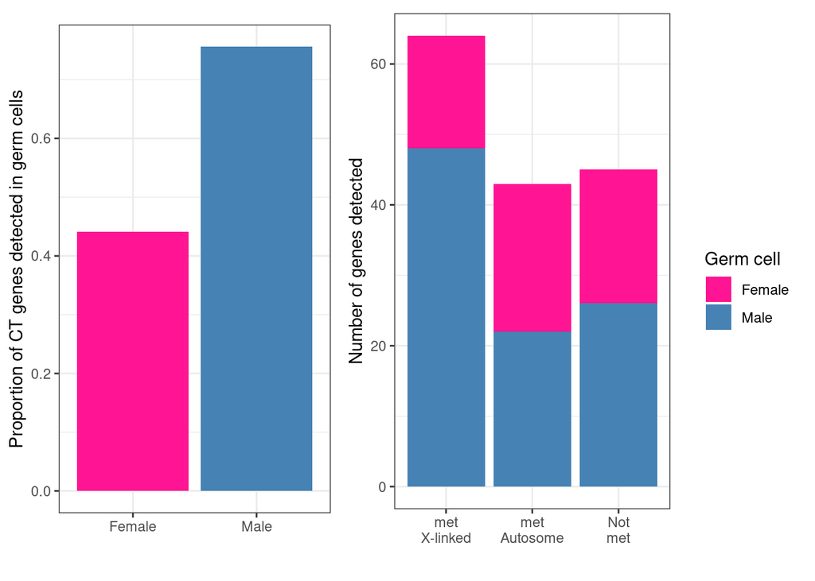

```r
fig <- cowplot::plot_grid(A + theme(legend.position = "none"),
                          B + theme(legend.position = "none"),
           rel_heights = c(1, 1))

legend <- cowplot::get_legend(B)
cowplot::plot_grid(fig, legend, align = "v", rel_widths = c(1, 0.2))
```